# BCVA Endpoint Modelling for Trial Simulation

**Panel G — the endpoint.** Translating the arms into $\ge 15$L gainer rates: the naive lift *rises* with baseline (9.5 pp at BL50 → 13.9 pp at BL70), while the realistic lift *falls* (12.2 pp at BL50 → 10.4 pp at BL70), the two crossing near the population mean. The realistic decline is the intuitive story from Panel E — less headroom, fewer letters, smaller lift. The naive *rise* is a subtle artefact of the ceiling-blind flat-3L assumption (the gainer *rate* still falls in both arms; it is only the treatment-minus-control *difference* that grows, because eyes pile up just below the threshold near the ceiling). The mechanism and a density picture are in Section 17, kept out of the main line to avoid derailing it. The control curve is the **active anti-VEGF comparator** (§8.2.1), so it already sits near 50% gainers at baseline 50; the black points overlay the **observed pooled active-arm gainer rate by baseline band** (§5, Wilson 95% CIs) and the engine’s comparator curve tracks them to within a few percentage points. Table 6 reads off baselines 50-70.

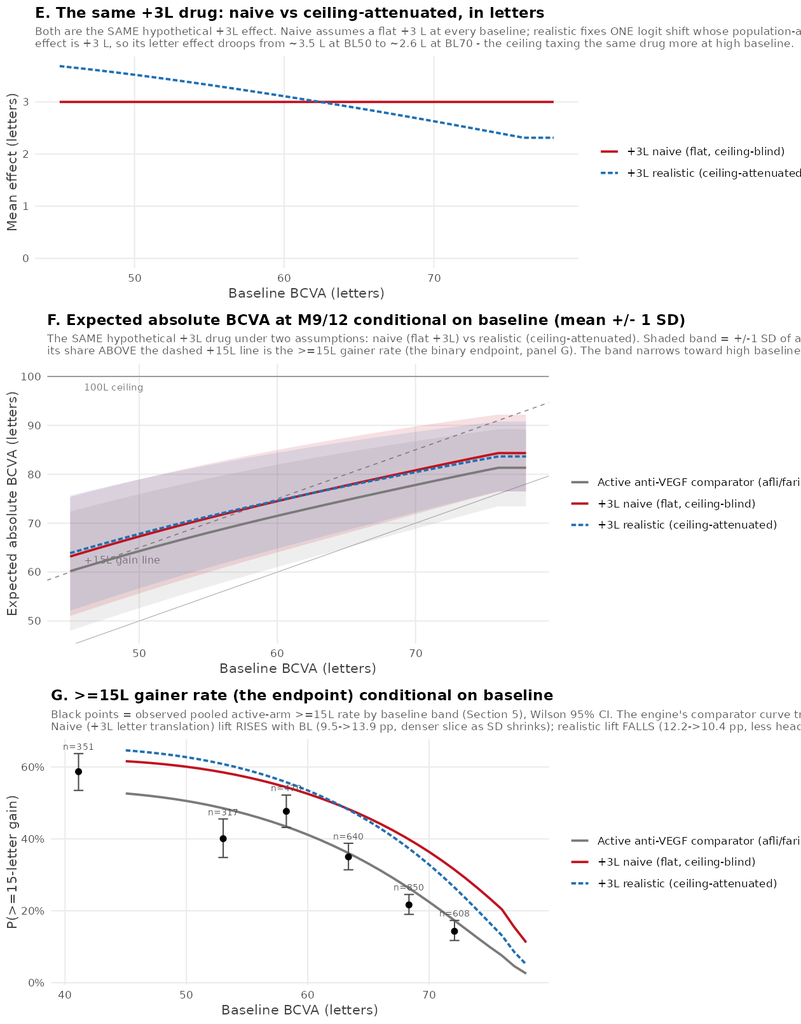

Figure 15: Expected absolute BCVA at M9/12 conditional on baseline, read top to bottom in the order the logic runs: effect -> distribution -> endpoint. The reference arm is the ACTIVE anti-VEGF comparator (aflibercept/faricimab), not sham; the endpoint is the >=15L gainer throughout; the two treatment arms are the SAME hypothetical +3L drug under two assumptions (naive = pure +3-letter translation, ceiling-blind; realistic = fixed logit shift, ceiling-attenuated, population-average +3L). E: the drug in letters under the two assumptions - naive is a constant 3 L translation; realistic droops from ~3.5 L at BL50 to ~2.6 L at BL70 (population-average = 3 L) because the fixed logit shift is scaled by the Jacobian J=100*q*(1-q) near the ceiling, where q=BCVA/100 is the mean as a fraction of the cap (NOT a probability; and J is the slope at the mean, the exact letters use the quadrature average). F: expected absolute BCVA for the three arms with a +/-1 SD ribbon; the dashed line is baseline+15 (the >=15L gain threshold), the flat grey line the 100L ceiling. The SHARE of each arm’s SD ribbon lying ABOVE the +15L line is that arm’s >=15L gainer rate - so panel F is the continuous distribution and panel G its dichotomisation. The naive ribbon is the control ribbon shifted up 3 L (translation preserves SD); the comparator/realistic ribbons narrow toward high baseline as the ceiling compresses the outcome SD, which is why the binary cut loses information there. G: >=15L gainer rate (the endpoint); black points = observed pooled active-arm gainer rate by baseline band (Section 5) with Wilson 95% CIs and n annotated - the engine’s comparator curve tracks the data. The naive lift RISES with baseline (9.5->13.9 pp across BL50-70) because a fixed 3-letter window [BL+12,BL+15] catches a denser slice of the control distribution as the letter-scale SD shrinks (11.7->9.0 L); the realistic lift FALLS (12.2->10.4 pp) as headroom disappears, and the two cross near the population mean. Fitted logit-normal engine, analytic (Gauss-Hermite).

Table 6: Expected absolute BCVA and >=15-letter gainer rate at M9/12, conditional on individual baseline (50-70), for the SAME hypothetical +3L drug under two assumptions. The ‘comparator’ columns are the ACTIVE anti-VEGF arm (aflibercept/faricimab), not sham - hence ~50% gainers at baseline 50, consistent with the observed pooled active-arm rates in Section 5. The endpoint is the >=15L gainer throughout; ‘+3L’ names the true MEAN effect, not a gainer threshold. ‘+3L naive’ is a pure +3-letter translation (Y_trt=Y_ctrl+3, ceiling-blind, SD unchanged); ‘+3L realistic’ fixes one logit shift with population-average effect 3 L, so its letter effect (column ‘+3L realistic, effect in letters’) is >3 L at low baseline (3.52 L at BL50) and <3 L at high baseline (2.63 L at BL70). The two gainer-lift columns move in OPPOSITE directions: the naive lift RISES with baseline (9.5/10.3/11.4/12.7/13.9 pp) because the fixed 3-letter window [BL+12,BL+15] catches a denser slice of the control distribution as the letter-scale SD shrinks toward the ceiling; the realistic lift FALLS (12.2->10.4 pp) as headroom disappears. They cross near the population mean - realistic EXCEEDS naive at low baseline (12.2 vs 9.5 pp) and falls below it at high baseline (10.4 vs 13.9 pp).

| Baseline BCVA | E[abs BCVA] comparator | E[abs BCVA], +3L naive | +3L realistic, effect in letters | >=15L gainers, comparator | >=15L gainers, +3L naive | >=15L gainer lift, +3L naive (pp) | >=15L gainer lift, +3L realistic (pp) |
| --- | --- | --- | --- | --- | --- | --- | --- |
| 50 | 64.3 | 67.3 | 3.52 L | 50.5% | 60.1% | 9.5 | 12.2 |
| 55 | 68.0 | 71.0 | 3.33 L | 46.8% | 57.1% | 10.3 | 12.3 |
| 60 | 71.5 | 74.5 | 3.11 L | 41.2% | 52.5% | 11.4 | 12.3 |
| 65 | 74.7 | 77.7 | 2.88 L | 33.1% | 45.8% | 12.7 | 11.9 |
| 70 | 77.8 | 80.8 | 2.63 L | 22.5% | 36.4% | 13.9 | 10.4 |

That is the whole of Part 1: a defensible baseline axis (Assumption A, matched to the real trials) and an honest effect that the ceiling attenuates (Assumption B), read out as absolute BCVA and $\ge 15$L gainer rates. Everything the designer sees directly — letters gained, percent gaining $\ge 15$ — lives in Figure 15 and Table 6. Part 2 takes the one further step of converting this into *statistical efficiency*.

### 8.2.3 Part 2 — The efficiency (ARE) consequence

Part 1 gave the picture in letters. The design question is narrower: **given the ceiling-attenuated modern signal, how much does dichotomising at 15 letters cost — and why is that cost higher now than in the MARINA/ANCHOR era?** Three answers, one figure each. The efficiency metric throughout is the ARE of the $\ge 15$L endpoint versus a continuous mean-change analysis on the same data: $\text{ARE}=N_{\text{cont}}/N_{\text{bin}}$, so $1/\text{ARE}$ is the extra eyes the binary cut costs. The full derivation is in Section 8.1.1; everything below is the exact logit-normal engine (Gauss–Hermite, no simulation).

**Two ARE objects, and how they relate.** Throughout this subsection two ARE curves appear side by side, and it is worth naming them against the closed form of Section 8.1.1 up front:

- the **closed-form Normal ARE**, $\text{ARE}(z_0)=\varphi(z_0)^2/[p(1-p)]$ with $p=\Phi(z_0)$ and $z_0=(\mu-15)/\sigma$ — a *shape-free* benchmark that depends on the outcome only through its mean and SD (via $z_0$). This is the **“equiv Normal”** column of Table 8 and the **blue** curve of Figure 18: it is evaluated at the engine’s own ceiling-compressed $\mu(BL_0)$ and $\text{SD}(BL_0)$, so it carries the ceiling’s effect on the *moments* but discards its effect on the *shape*.
- the **exact logit-normal ARE**, $\text{ARE}(BL_0,\Delta)=N_{\text{cont}}/N_{\text{bin}}$ from the Step-1–5 recipe of Section 8.1.2 — the **red** curve — which additionally carries the bounded, left-skewed *shape*.

Their gap is the **pure shape penalty** (point 3 below): small (~5% at BL50, ~14% at BL70), confirming that $\text{ARE}(z_0)$ is an accurate approximation once $z_0$ is read off the *actual* ceiling-compressed moments.

**1 — The 15L cut is wasteful for a small effect, cheap for a large one; the ceiling pushes modern drugs into the wasteful zone.** Figure 16 panel A sweeps the true effect at each baseline. At *every* baseline a bigger true effect lifts the ARE: the +15L threshold moves out of the far tail and into the body of the treated distribution, so the cut discards less. A modern **+3L** sits on the wasteful left flank (ARE ≈ 0.65–0.70, i.e. ~1.5× the eyes); a historical **+15–20L** sits far to the right where the cut is nearly free. This is the core reason the $\ge 15$L endpoint has aged badly: the *achievable* increment over an active comparator collapsed from ~15–20L (versus the deteriorating sham/PDT controls of MARINA and ANCHOR) to ~3L today.

The baseline curves **cross near +4L**, and the reason is instructive. High baseline does two opposing things to the cut. It pushes the control gainer rate $p$ out into the tail (0.51→0.23 from BL50 to BL70), where the threshold density is low — so for a **small** effect high baseline is slightly *worse* (the red BL70 line sits below green BL50 at +3L). But high baseline also compresses the SD, so a **large** effect clears almost the entire distribution — near-total separation, tiny binary N — and high baseline becomes far *better* (the red line shoots above at +15L, ARE→1.8). Hence the reversal in the red line between +3L and +15L.

The catch is that you cannot actually *reach* that favourable high-baseline, large-effect corner, because the same ceiling **attenuates a real drug back down** — and this is the mechanism panel B makes explicit (it also underlies point 2). The ceiling scales *both* the achievable effect *and* the SD of change by the same factor, so as baseline rises they shrink in near-lockstep: a drug delivering +15L at BL50 gives only ~10.5L at BL70, and a +3L drug drops to ~2.3L, while the SD falls proportionally (11.7→9.0L). Because effect and SD move together, the *standardized* effect $\delta/\sigma$ — and hence continuous power — is preserved; but the achieved **letters** fall, sliding a programme **leftward** along panel A into the expensive zone. The era shift is therefore two moves at once: a smaller true effect (active comparator) *and* a higher baseline (attenuation), both pushing left.

**What the % axis assumes — and what it does not**

Panel B plots each curve as a percentage of **its own value at baseline 50** — so all three start at 100% and the *shrinkage* is read off directly. Worked example for the +3L drug, whose engine effects are 3.00 L at BL50, 2.65 L at BL60 and 2.25 L at BL70:

$$\frac{3.00}{3.00}=100\%,\qquad
\frac{2.65}{3.00}=88\%,\qquad
\frac{2.25}{3.00}=75\%.$$

The **only** assumption baked into this view is the *anchor*: we calibrated each drug so its full effect (3 L or 15 L) lands at BL50, then let the ceiling attenuate upward from there, so “BL50 = 100% = undamaged” is a choice. It affects only where the 100% line sits — the *ratios between baselines* (and hence the lockstep) are anchor-free: anchoring at BL70 instead would simply relabel BL50 as $3.00/2.25 = 133\%$, same curves shifted. The claim the panel actually makes — that continuous power is preserved — rests on the **standardized effect $\delta/\sigma$** (dotted, right axis), which is a raw ratio needing *no* anchor: $3.00/11.66 = 0.257$ at BL50, $2.65/10.47 = 0.253$ at BL60, $2.25/8.96 = 0.251$ at BL70 — flat to ~2% for the +3L drug (and only mildly declining, 1.29→1.17, for the +15L drug, since the exact effect/SD cancellation holds in the small-shift limit). The lockstep of the % lines is the *visual* story; the flat $\delta/\sigma$ is the *anchor-free* proof.

There is also a genuine **modelling** assumption underneath, separate from the plot: the drug is taken to be a constant shift on the **logit scale**, quoted at BL50. That single logit shift mechanically produces less effect at high baseline via the arithmetic ceiling. A drug that were instead constant *in letters*, or that weakened near the ceiling for pharmacological reasons, would give a different attenuation curve; the logit-shift model is the minimal (pure-arithmetic-ceiling) choice.

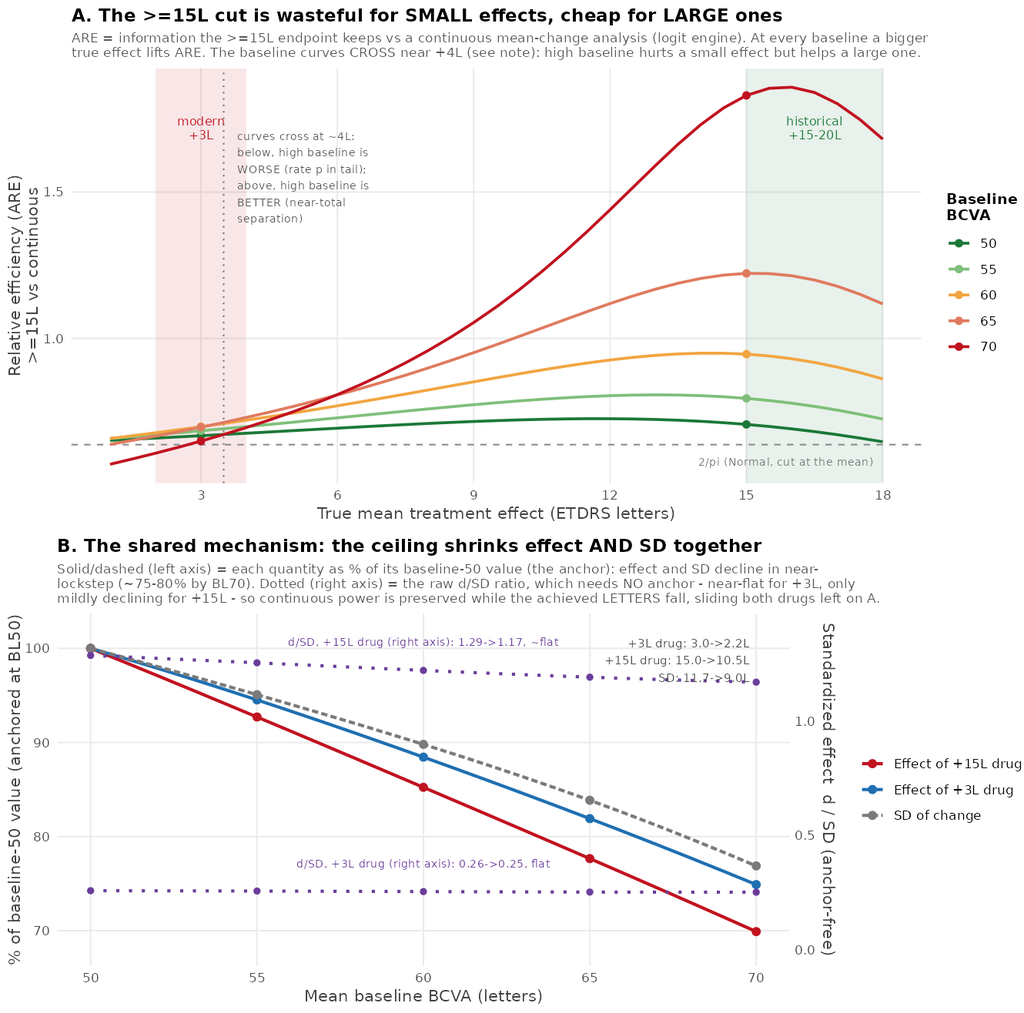

Figure 16: Why the >=15L cut costs more now than in the MARINA/ANCHOR era, logit engine, all baselines 50-70. A: ARE(>=15L vs continuous) vs the TRUE mean effect. At every baseline a bigger effect lifts efficiency; the modern +3L region (left) is wasteful, the historical +15-20L region (right) near-free. The baseline curves CROSS near +4L: for a small effect high baseline is worse (control rate p out in the tail), for a large effect it is better (compressed SD -> near-total separation). Points mark each baseline’s +3L and +15L; dashed 2/pi = best case. B: the shared ceiling mechanism (merges the old attenuation panel). Solid/dashed (left axis) = each quantity as % of its baseline-50 value (the anchor): the achievable effect of a +3L AND a +15L logit drug, and the SD of change, all decline in near-lockstep (~75-80% by BL70). Dotted (right axis) = the anchor-free standardized effect d/SD, which stays flat (+3L: 0.26->0.25) or only mildly declines (+15L: 1.29->1.17) - so continuous power is preserved while the achieved letters fall, sliding both drugs leftward along panel A.

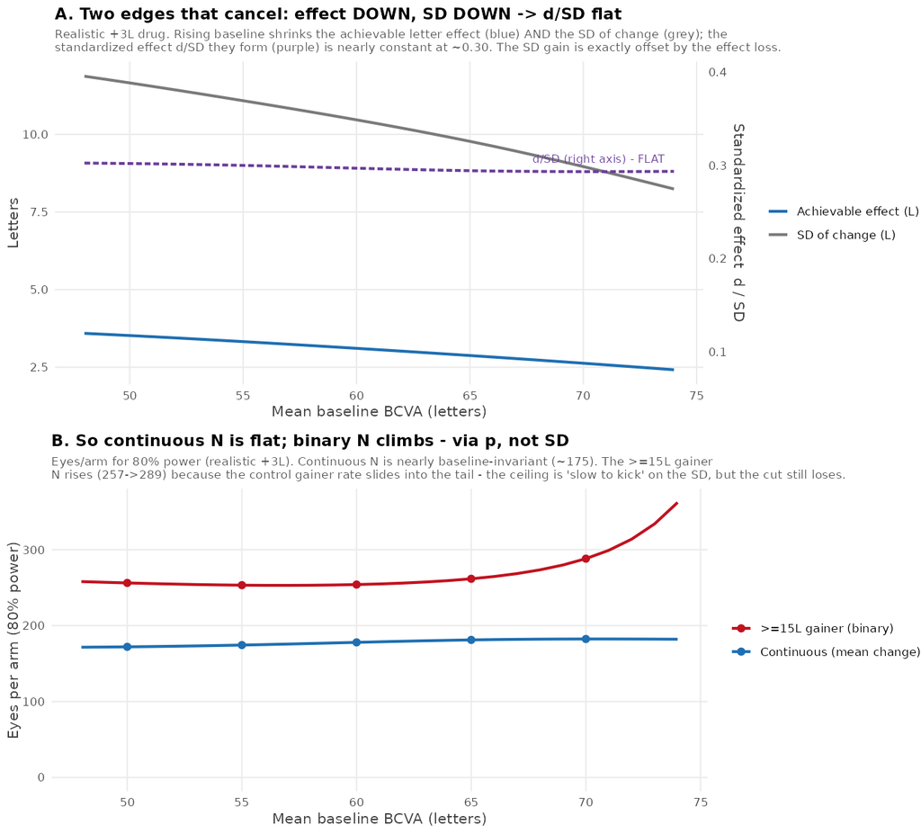

Figure 17: The ceiling’s SD reduction is double-edged for the continuous endpoint and barely bites the binary one; realistic +3L drug, logit engine. A: as baseline rises the achievable effect delta (blue) AND the SD of change (grey) both fall, in absolute letters; the standardized effect d/SD (purple, right axis) they form is nearly FLAT at ~0.30 - the two edges cancel. B: eyes/arm for 80% power. Continuous N is baseline-invariant (~175); the >=15L gainer N climbs (257->289) not because of the SD but because the control gainer rate slides into the tail.

Table 7: The ceiling’s effect on continuous-endpoint power, by baseline, for a realistic (ceiling-attenuated) +3L effect. Under a naive flat +3L the standardized effect d/SD rises and continuous N falls (238->141/arm) - a mirage that credits high-baseline trials with power a real drug cannot deliver into a ceiling. Under the realistic +3L, delta and SD fall together, d/SD is flat (~0.30), and continuous N is nearly baseline-invariant (173->183/arm). The two ceiling effects cancel.

| Baseline BCVA | SD of CFBL | Realistic effect | Std. effect d/SD (naive +3L) | Std. effect d/SD (realistic +3L) | N/arm continuous (naive) | N/arm continuous (realistic) |
| --- | --- | --- | --- | --- | --- | --- |
| 50 | 11.7 L | 3.52 L | 0.257 | 0.302 | 238 | 173 |
| 55 | 11.1 L | 3.33 L | 0.271 | 0.300 | 215 | 175 |
| 60 | 10.5 L | 3.11 L | 0.287 | 0.297 | 192 | 178 |
| 65 | 9.8 L | 2.88 L | 0.307 | 0.294 | 167 | 182 |
| 70 | 9.0 L | 2.63 L | 0.335 | 0.293 | 141 | 183 |

**What ‘matched on mean and SD’ means for the blue curve**

Both the mean change-from-baseline $\mu_c$ and its SD depend on baseline — and the blue Normal *inherits both from the engine at every baseline*. “Matched” does not mean fixed or constant across baseline; it means that at each $BL$ the Gaussian is given the engine’s own (baseline-varying) $\mu_c(BL)$ and $\sigma(BL)$, then its gainer rate is $p^N_c=\Phi\big((\mu_c-15)/\sigma\big)$, $p^N_t=\Phi\big((\mu_c+\Delta-15)/\sigma\big)$. The **only** information blue throws away is the ceiling’s *shape*. Concretely (realistic +3L drug):

| Baseline | ARE, logit engine (red, exact) | $\text{ARE}(z_0)=\varphi(z_0)^2/[p(1-p)]$ (blue, matched Normal) | shape penalty |
| --- | --- | --- | --- |
| 50 | 0.672 | 0.639 | −4.8% |
| 60 | 0.700 | 0.633 | −9.7% |
| 70 | 0.633 | 0.544 | −14.0% |

The gap is second-order — the shape matters, but far less than the operating rate, which moves the ARE much more across the same baseline range. The penalty is largest at high baseline, where the left-skew is most pronounced.

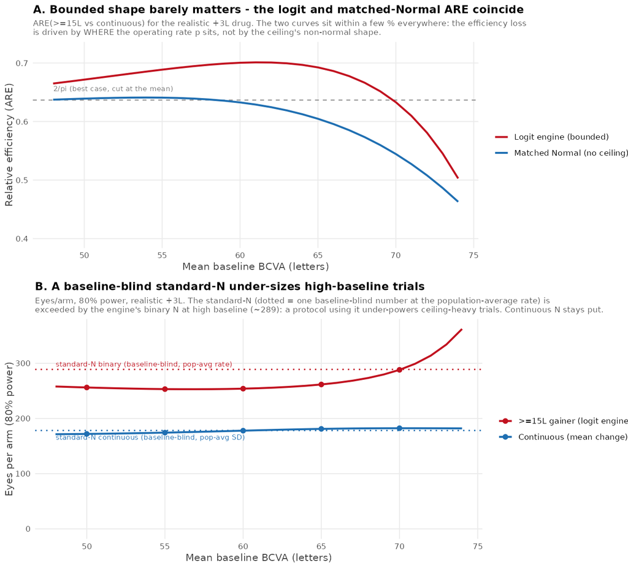

Figure 18: The bounded shape is second-order; a baseline-blind sample size is the real risk. Realistic +3L, logit engine. A: ARE(>=15L vs continuous) at each baseline. Both curves share the continuous side and differ only in how the >=15L gainer rate is read: RED from the true bounded logit tail (exact recipe, Section 8.1.2); BLUE from the closed-form Normal ARE(z0)=phi(z0)^2/[p(1-p)] (Section 8.1.1) evaluated at the engine’s OWN mean and SD at that baseline (so blue keeps the ceiling’s effect on the moments but discards its effect on the shape). The red-blue gap is the pure shape penalty - ~5% at baseline 50, ~14% at baseline 70 - so the loss is driven by where the operating rate p sits, not by the non-normal shape. B: eyes/arm. The baseline-blind standard-N (dotted, one number at the population-average rate) is exceeded by the engine’s binary N at high baseline (~289) - a protocol using it under-powers ceiling-heavy trials. Continuous N stays near its standard line.

| Baseline BCVA | True mean effect | Gainers ctrl | Gainers trt | Gainer diff | SD of CFBL | ARE (binary vs continuous) | N x (dichotomising) | ARE (equiv Normal) | Extra ceiling penalty |
| --- | --- | --- | --- | --- | --- | --- | --- | --- | --- |
| 50 | 3 L | 50.5% | 60.9% | 10.4 pp | 11.7 L | 0.644 | 1.55 x | 0.636 | -1% |
| 55 | 3 L | 46.8% | 57.9% | 11.1 pp | 11.1 L | 0.645 | 1.55 x | 0.629 | -3% |
| 60 | 3 L | 41.2% | 53.0% | 11.9 pp | 10.5 L | 0.639 | 1.56 x | 0.611 | -5% |
| 65 | 3 L | 33.1% | 45.5% | 12.4 pp | 9.8 L | 0.611 | 1.64 x | 0.572 | -7% |
| 70 | 3 L | 22.5% | 34.5% | 12.1 pp | 9.0 L | 0.535 | 1.87 x | 0.502 | -7% |

| Baseline BCVA | SD of CFBL | Gainer diff (+3L) | N/arm continuous | N/arm >=15L gainer | Ratio (binary/cont) | = 1/ARE |
| --- | --- | --- | --- | --- | --- | --- |
| 50 | 11.7 L | 10.4 pp | 238 | 356 | 1.50 x | 1.55 |
| 55 | 11.1 L | 11.1 pp | 215 | 314 | 1.46 x | 1.55 |
| 60 | 10.5 L | 11.9 pp | 192 | 274 | 1.43 x | 1.56 |
| 65 | 9.8 L | 12.4 pp | 167 | 240 | 1.44 x | 1.64 |
| 70 | 9.0 L | 12.1 pp | 141 | 216 | 1.54 x | 1.87 |

**Reading the ARE as eyes**

The eyes/arm figures use the standard two-arm, two-sided 5%, 80%-power formulas ($z_{\alpha/2}=1.96$, $z_\beta=0.842$): continuous $n_{\text{cont}} = 2\,(z_{\alpha/2}+z_\beta)^2\, \mathrm{SD}^2 / \Delta^2$; binary $n_{\text{bin}} = (z_{\alpha/2}+z_\beta)^2\,[\,p_c(1-p_c)+p_t(1-p_t)\,]/(p_t-p_c)^2$. Their ratio $n_{\text{bin}}/n_{\text{cont}}$ equals $1/\text{ARE}$ at a small effect — the multiplier on trial size you pay for dichotomising.

The ARE is *local* (linearised at the null) and *marginal* (it ignores baseline covariate-adjustment and the between-eye correlation a real analysis exploits). The simulation study below sweeps $N$, true effect $\Delta$, and baseline mean jointly, running the actual analysis models on data from the fitted engine, to turn these efficiency ratios into the quantity a protocol needs: **power at a given $N$**.

## 8.3 Power and sample size across baseline, effect, and N

Running the harness over a grid of **baseline mean × true effect × eyes-per-arm** turns the endpoint-efficiency argument into concrete design numbers. The engine is the selected conditional-ANCOVA LogitNormal (Section 7.4): a between-eye random effect on the logit scale and a baseline-dependent residual SD $\sigma(\text{BL})$, both extracted from the fitted per-arm posterior curves (`results/brms/rhine_arm_curves.csv`). The reference arm is the pooled **aflibercept active comparator** (RHINE + YOSEMITE, M9/M12, $n=1082$): its logit-mean curve $\eta_{\text{control}}(\text{BL})$ *is* the control response, and the treatment arm is $\eta_{\text{control}}(\text{BL}) + \Delta$ with $\Delta$ applied per subject in letters. The engine is recalibrated by a single logit offset so the simulated control $\ge15$-letter gainer rate matches the observed anchor (0.314) at the reference baseline.

The sweep runs **5 baseline means** (50–74 L) × **6 effects** ($\Delta = 0,2,3,4,5,7$ L) × **8 sample sizes** (25–400 eyes/arm), **3000 trials per cell**, on the **selected final model** — the LogitNormal cANCOVA with the fitted **Student-$t$ eye random effect** ($\nu=4.3$, Section 7.7) and a **constant residual SD** (Section 14). Each simulated trial is analysed by **15 methods**: six continuous (a two-sample $t$-test on change and on the absolute endpoint; the baseline-adjusted ANCOVA on each; a Wilcoxon rank-sum on change; and a **rank-based (normal-scores) ANCOVA on the absolute endpoint**, Section 8.3.7) and three binary — `prop.test` (risk difference) and logistic regression with and without baseline adjustment (odds ratio) — each evaluated at three responder thresholds ($\ge5$, $\ge10$, $\ge15$ letters). The full grid is `results/s8_power_grid.csv`; the self-contained generator + analyses + sweep are merged in `21_s8_sweep.R`.

The swept $\Delta$ is a **superiority increment over active control**, in letters — added on top of the control response. Aflibercept itself already gains ~10.9 letters from baseline in these DME data (Section 4); the treatment arm gains that **plus** $\Delta$. The fitted faricimab-6 mg-vs-aflibercept contrast is only ~0.8 letters (the two active arms are near-equivalent by design), so it is a realism marker on the $\Delta$ axis, not the axis itself — powering a superiority trial to detect 0.8 letters is not the design question. The grid therefore sweeps $\Delta$ from 2 to 7 letters, spanning the modern 2–3 L target through the historical ~5 L.

### 8.3.1 Simulation summary

Each simulated trial is generated one eye at a time through the selected Section 6 LogitNormal conditional-ANCOVA, then analysed by all fifteen methods; power is the rejection rate over the 3000 trials in a cell. The generator draws, for eye $i$ in arm $a$ at baseline $\text{BL}_i$,

$$Y_i = 100\,\operatorname{plogis}\!\Big(
\underbrace{\eta_{\text{control}}(\text{BL}_i) + o}_{\text{control mean curve}}
+ \underbrace{a\,\Delta_i}_{\text{treatment shift}}
+ \underbrace{u_i}_{\text{eye RE}}
+ \underbrace{\varepsilon_i}_{\text{residual}}\Big),
\quad
\varepsilon_i \sim \mathcal N\!\big(0,\ \sigma^2\big),$$

with the **Student-$t$ eye random effect** of the selected model, $u_i = s_t\,t_\nu$ ($\nu=4.3$, scale $s_t=0.368$ so the marginal SD is 0.505 logit), a **constant residual SD** $\sigma=0.205$ logit, a single calibration offset $o$, and $a\in\{0,1\}$. The per-eye treatment shift $\Delta_i$ is the $\Delta$-letter increment mapped to the logit scale through the local inverse Jacobian at $\text{BL}_i$, so the realised mean letter effect stays at the swept $\Delta$ across baselines. This is the same linear predictor as the fitted Section 6 model (Section 6.2) restricted to the post rows, with the arm term gated on and the study/visit terms folded into the pooled aflibercept reference curve.

The eye RE here uses the **genuinely fitted** Student-$t$ parameters ($\nu=4.3$, $s_t=0.368$; 1) — it is *not* the idealised variance-matched redraw of Section 7.7.1, which imposed the Gaussian’s variance on the tail by construction to isolate shape from scale. No such constraint is applied in the generator. The fitted $t$ nonetheless carries a marginal RE SD (0.505 logit) that lands within ~2% of the Gaussian $\tau$ (0.496) on its own, because the data drove both fits to essentially the same second moment (Section 7.7.3). The practical consequence is that the total logit variability the sweep injects, $\sqrt{\tau^2+\sigma^2}=0.536$, is the same to within Monte-Carlo noise whether the eye RE is Gaussian or the fitted $t$, so power and Type-I turn on the mean effect and gainer rate (both well covered under either RE), while the heavier tail improves only the extreme-percentile realism (per-arm SD, %ceiling) that the responder-vs-continuous comparison of Section 8.3.4 leans on.

**The Section 6 baseline spline $f_{\text{fam}}(\text{BL})$ is carried in full — it is not linearised.** The control mean $\eta_{\text{control}}(\text{BL})$ is the fitted `post:ns(BL,4)` natural-cubic-spline term (the “regression to ceiling” term of Section 6.2), exported on a 60-point baseline grid (25–76 L, 0.86-L spacing) as `results/brms/rhine_arm_curves.csv` and read back by the engine with `approxfun`. Because the grid is dense relative to the spline’s curvature, linear interpolation between knots reproduces the cubic spline to $<4\times10^{-5}$ logit units off-grid — the nonlinearity (local slope varying from 0.040 at BL 35 to 0.035 at BL 55, a 0.039 logit departure from a straight line) is preserved, so the ceiling-driven curvature that drives every result in this section is exactly the fitted one. The treatment arm adds $\Delta$ *on top of* this spline curve, so both arms inherit the identical $f_{\text{fam}}(\text{BL})$ shape and the ceiling acts on treated and control eyes alike — which is why Type-I is exact under $H_0$ and why the responder penalty grows with baseline (Section 8.3.5).

**Residual SD: constant, matching the selected model.** The model-selection scorecard chose the parsimonious **constant-$\sigma$ cANCOVA** over the baseline-varying $\sigma\sim\text{STUDY}+\text{ns(BL)}$ law (a $\Delta$AIC of ~177, Section 14): once baseline is a mean covariate and the response is on the logit scale, the letter-scale heteroscedasticity is reproduced by the bounded transform with no $\sigma$-spline needed. The engine therefore uses a **single residual SD** $\sigma=0.205$ logit — the baseline-density-weighted RMS of the exported per-arm residual curve at the reference scenario, which preserves the total residual variance (the total logit SD is $\sqrt{\tau^2+\sigma^2}=0.536$). Baseline-dependence of the *spread* thus enters only through the bounded LogitNormal transform (the ceiling compresses variance in letters near the cap), not through a separate $\sigma(\text{BL})$ term — exactly as in the selected model.

The design is a $5\times6\times8$ grid (baseline mean × effect × eyes/arm), **3000 trials per cell** = 720{,}000 simulated trials, each analysed by 15 methods (6 continuous + 3 binary × 3 thresholds). The engine is data-free: it runs entirely from the exported posterior curves and the documented control anchor, with no clinical records. Code: `21_s8_sweep.R` (self-contained generator + analyses + sweep), `22_s8_tables.R` / `23_s8_figures.R` (outputs).

### 8.3.2 Type-I error is controlled for every method

Before reading any power number, the $\Delta=0$ slice confirms every analysis holds its size. Across all baseline × N cells the rejection rate at $\Delta=0$ sits within simulation error of the nominal 5% — median 0.049, whole-grid range [0.013, 0.061], consistent with the $\pm0.008$ Monte-Carlo band at 3000 trials. The `prop.test` risk-difference at the $\ge15$-letter threshold is if anything mildly conservative in the smallest-N, highest-baseline cells (sparse gainer counts). Type-I is robust by construction here: under $H_0$ the generator is identical in the two arms, so the ceiling and the baseline distribution cancel.

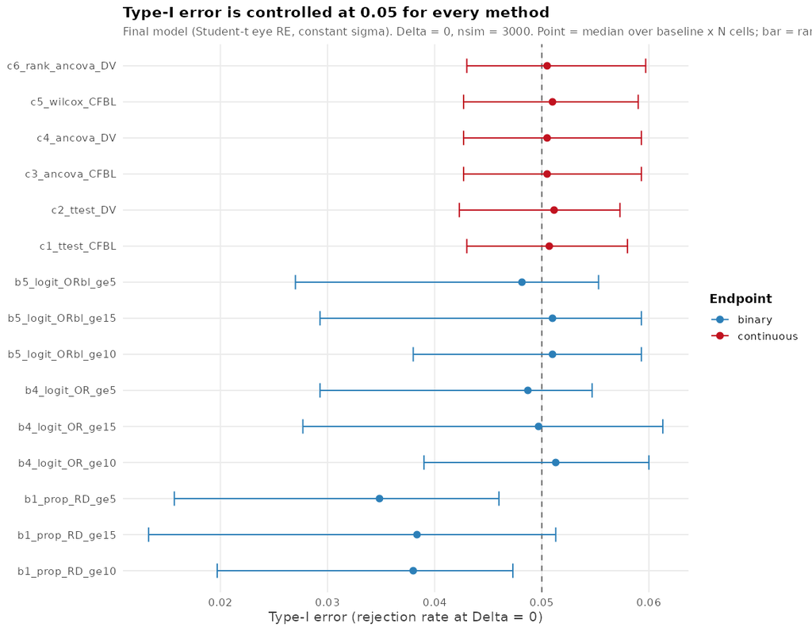

### 8.3.3 Power vs sample size, and the endpoint hierarchy

Figure 19 reads power against eyes-per-arm at a **3-letter increment** (the modern superiority target), faceted by baseline. The ordering is the same at every baseline and is the central result of the section: the **baseline-adjusted continuous ANCOVA** needs the fewest eyes, the **unadjusted change $t$-test** a few more, and the **$\ge15$-letter responder** analyses (whether risk-difference or odds-ratio) need substantially more to reach the same power. At baseline 62 and $\Delta=3$, the continuous ANCOVA clears 80% power by ~170 eyes/arm while the $\ge15$L responder endpoints need 270–350.

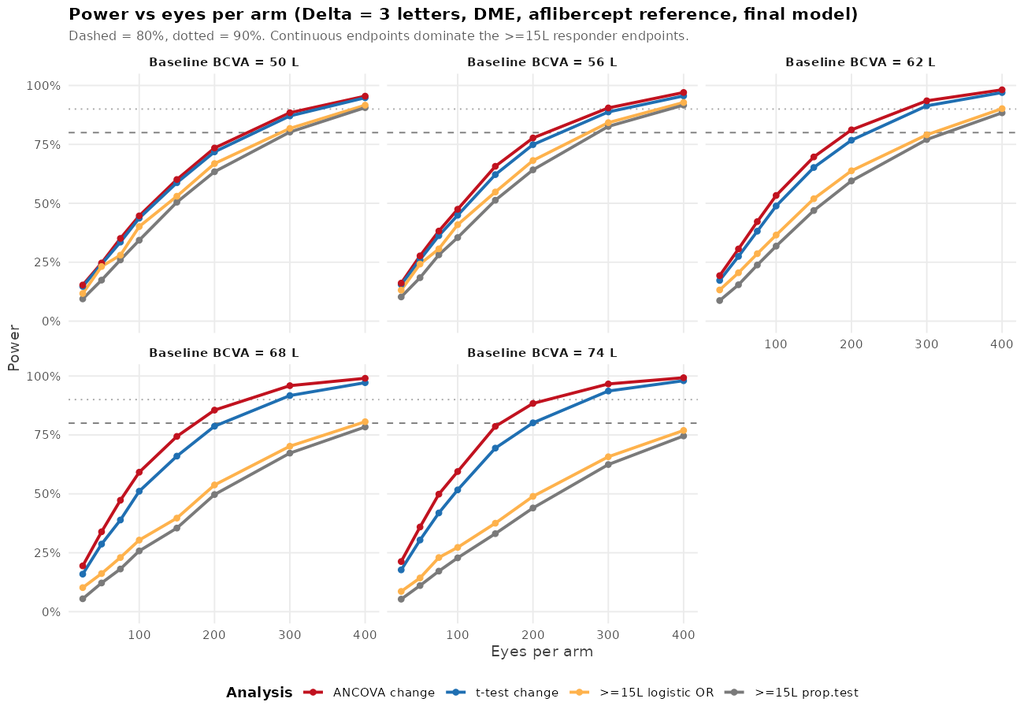

Figure 19: Power vs eyes per arm at a 3-letter increment, faceted by mean baseline BCVA (final model: Student-t eye RE, constant sigma; aflibercept reference). Dashed = 80%, dotted = 90%. The continuous analyses (baseline-adjusted ANCOVA, then the change t-test) dominate the >=15-letter responder analyses at every baseline; the gap is the dichotomisation penalty quantified in Section 8.3.4.

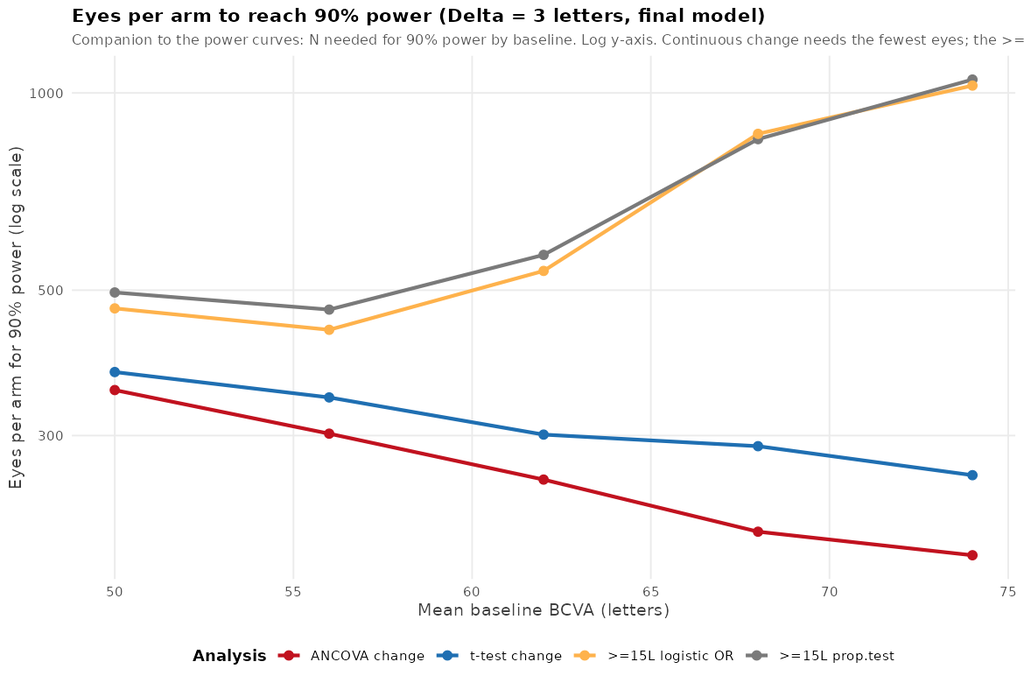

### 8.3.4 Dichotomisation loss and the equivalent sample size

The efficiency cost of the FDA-favoured responder endpoint is most usefully expressed as an **equivalent sample size**: the eyes/arm each analysis needs to reach 80% power, relative to the baseline-adjusted linear change-ANCOVA (the reference, =1.0). Figure 21 reports this ratio at $\Delta=3$ L and baseline 62. The **rank-based ANCOVA (Section 8.3.7) is the most efficient analysis of all** — 140 eyes/arm, a 0.82× ratio (18% *fewer* eyes than the linear reference) — followed by the Wilcoxon on change and the two linear adjusted analyses at ~1.0. Against that continuous frontier, dichotomising the response at $\ge15$ letters costs a **2.1× sample-size penalty** on the risk-difference scale (352 vs 170 eyes/arm); even the best responder analysis (the baseline-adjusted odds ratio) carries a **1.6×** penalty (270 vs 170). Lower thresholds cost a little less because they sit nearer the centre of the change distribution — the $\ge5$-letter baseline-adjusted odds ratio is a 1.6× penalty — but every dichotomisation is a net loss against the continuous endpoint. This is the ophthalmology-specific counterpart to the textbook information-loss argument of Section 8.1, now measured in eyes.

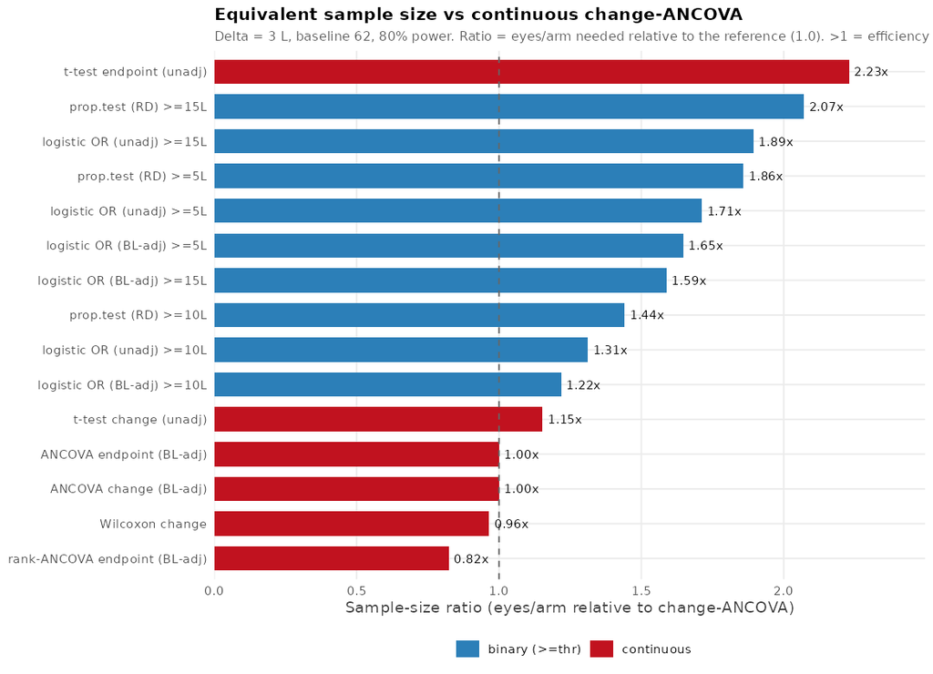

Figure 21: Equivalent sample size at 80% power relative to the baseline-adjusted linear change-ANCOVA (=1.0), Delta=3 L, baseline 62. Bars are eyes/arm needed as a multiple of the reference; >1 is an efficiency loss, <1 a gain. The rank-based ANCOVA (Section 8.3.7) sits below 1.0 (the most efficient analysis); the linear adjusted analyses cluster at 1.0; every >=k-letter dichotomisation costs 1.2-2.1x, worst at the >=15-letter FDA endpoint on the risk-difference scale.

Table 10: Equivalent sample size at Delta=3 L, baseline 62, final model (Student-t eye RE, constant sigma). SS ratio = eyes/arm relative to the baseline-adjusted linear change-ANCOVA (=1.0). The rank-based ANCOVA (Section 8.3.7) is the most efficient analysis at 0.82x (18% fewer eyes); the linear adjusted analyses sit at 1.0 and the unadjusted continuous analyses at 1.15-2.2; every binary dichotomisation costs 1.2-2.1x.

| Analysis | Eyes/arm (80%) | SS ratio | Extra % |
| --- | --- | --- | --- |
| rank-ANCOVA endpoint (BL-adj) | 140 | 0.82 | -18 |
| Wilcoxon change | 164 | 0.96 | -4 |
| ANCOVA change (BL-adj) | 170 | 1.00 | 0 |
| ANCOVA endpoint (BL-adj) | 170 | 1.00 | 0 |
| t-test change (unadj) | 196 | 1.15 | 15 |
| logistic OR (BL-adj) >=10L | 207 | 1.22 | 22 |
| logistic OR (unadj) >=10L | 223 | 1.31 | 31 |
| prop.test (RD) >=10L | 245 | 1.44 | 44 |
| logistic OR (BL-adj) >=15L | 270 | 1.59 | 59 |
| logistic OR (BL-adj) >=5L | 280 | 1.65 | 65 |
| logistic OR (unadj) >=5L | 291 | 1.71 | 71 |
| prop.test (RD) >=5L | 316 | 1.86 | 86 |
| logistic OR (unadj) >=15L | 322 | 1.89 | 89 |
| prop.test (RD) >=15L | 352 | 2.07 | 107 |
| t-test endpoint (unadj) | 379 | 2.23 | 123 |

### 8.3.5 The ceiling bite: why the penalty grows with baseline

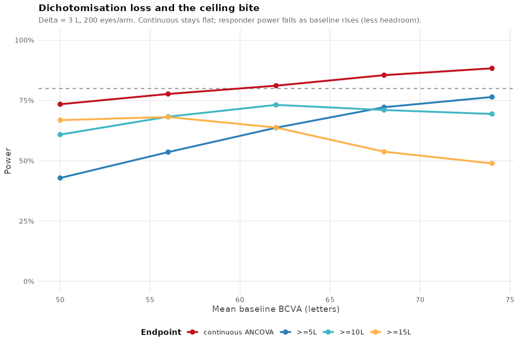

### 8.3.6 Baseline adjustment and the absolute-vs-change scale

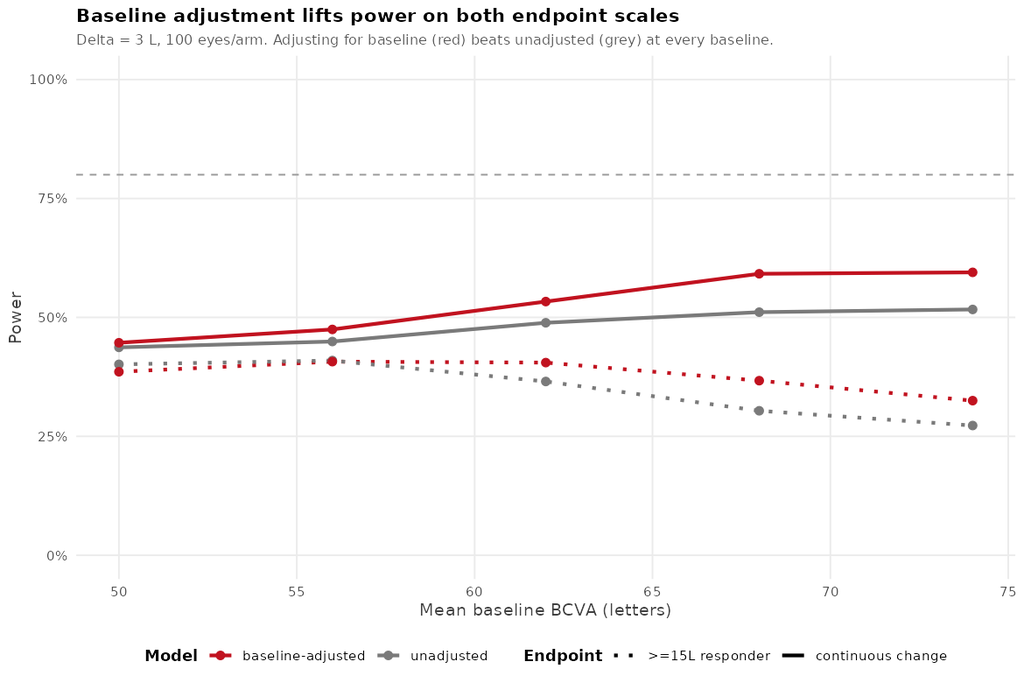

Second, the **absolute endpoint vs change-from-baseline** scale. These are often treated as different endpoints, but once baseline is in the model they are algebraically the same test: `DV ~ ARM + BL` and `(DV-BL) ~ ARM + BL` give identical ARM inference, and the grid confirms it — the two baseline-adjusted analyses collapse onto a **single line** in Figure 24 (plotted as one series precisely because they are indistinguishable). The scales diverge only when baseline is **omitted**: an unadjusted $t$-test on the absolute endpoint is far weaker than the same test on change (379 vs 196 eyes/arm at baseline 62), because it carries the full between-eye baseline spread as noise. The practical reading is that it is **baseline adjustment, not the choice of absolute-vs-change scale, that matters** — with adjustment the scale is a free choice; without it, analyse change, not the absolute endpoint.

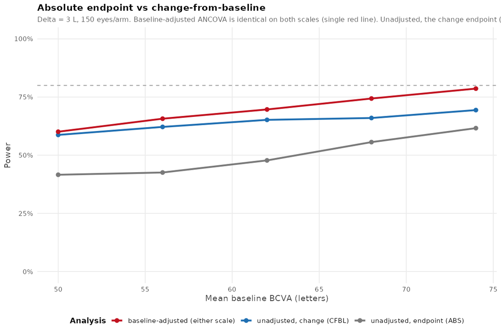

Figure 24: Absolute endpoint vs change-from-baseline (Delta=3 L, 150 eyes/arm). Red = baseline-adjusted ANCOVA, which is identical on the absolute and change scales and is therefore drawn as one line. Blue = unadjusted t-test on change; grey = unadjusted t-test on the absolute endpoint. The unadjusted absolute endpoint is far weaker; baseline adjustment, not the response scale, is what drives power.

### 8.3.7 A rank-based ANCOVA recovers power the linear model leaves behind

The absolute-vs-change equivalence of Section 8.3.6 is a property of the **linear** ANCOVA only. It holds because subtracting the baseline is a linear operation that the OLS fit absorbs into the baseline coefficient: moving BL to the right-hand side shifts its slope by exactly one and leaves the ARM estimate, its standard error, and its $p$-value untouched (verified to machine precision across the grid). The moment the analysis stops being linear — a rank-sum, a proportional-odds model — the equivalence breaks, because a nonlinear transform does not commute with subtraction: $\operatorname{rank}(Y-\text{BL})\neq\operatorname{rank}(Y)$. This is the distinction [Senn (2006)](https://pubmed.ncbi.nlm.nih.gov/16217847/) and [Harrell](https://www.fharrell.com/post/errmed/#change) draw when they caution against analysing change scores: the critique is not only about the well-known efficiency loss of an *unadjusted* change score when baseline and endpoint are correlated (Section 8.3.6), it is that a change score forces the baseline slope to be exactly one and, under any non-linear or rank analysis, can bias the treatment contrast. Our linear ANCOVA sidesteps that by estimating the baseline slope freely and by being scale-invariant — but it pays for its convenience by assuming the residual is approximately Normal, which the LogitNormal-with-ceiling response (Section 4.4) is not.

That motivates a sixth continuous analysis: a **rank-based ANCOVA on the absolute endpoint**. The endpoint is replaced by its **normal (van der Waerden) score** — a monotone rank transform — and analysed by the same linear ANCOVA on the arm term, `lm(normal_score(Y) ~ ARM + BL)`. This is Harrell’s fast, close approximation to the **proportional-odds model**: it is invariant to any monotone transform of the response (so the ceiling and the skew do not distort it) and still conditions on baseline as a free covariate rather than forcing a unit slope, yet it costs the same as an ordinary least-squares fit rather than an iterative ordinal likelihood. On this DGP it is expected to be *more* efficient than the Gaussian OLS ANCOVA precisely because the response is non-normal. We verified that the normal-scores ANCOVA reproduces the power and Type-I of a full proportional-odds fit (`polr` on a 25-level ordinal score) to within Monte-Carlo error while running roughly two orders of magnitude faster, so it is the form carried in the sweep.

The only difference from the standard ANCOVA is a one-off transform of the *response*; the right-hand side of the model — the arm contrast and the raw baseline covariate — is identical:

```
standard ANCOVA:   Y ───────────────────────────────────▶ lm( Y ~ arm + BL ) ──▶ arm effect, p
rank    ANCOVA:    Y ─rank─▶ R ─(R−0.375)/(n+0.25)─▶ p ─qnorm─▶ z ─▶ lm( z ~ arm + BL ) ──▶ arm effect, p
c6                                                                        └─ BL enters here, RAW (never ranked)
```

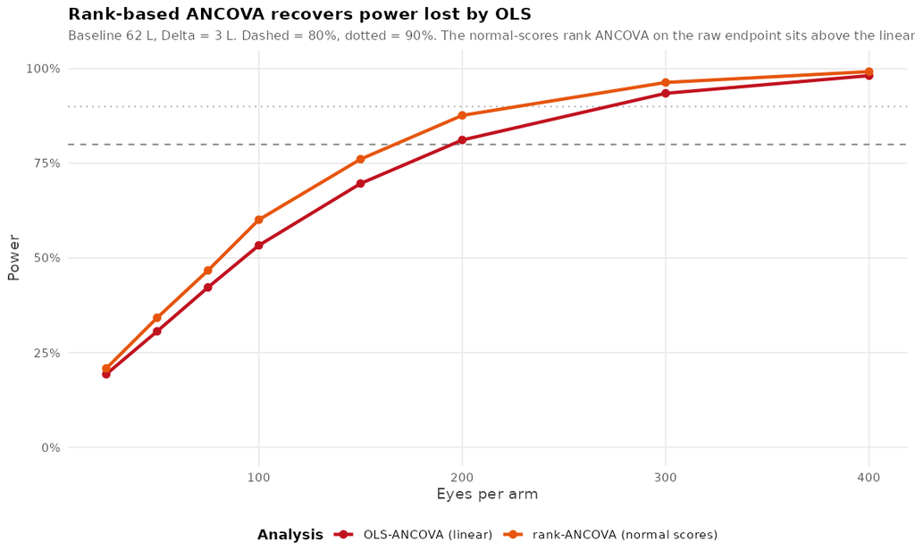

Figure 25: Rank-based (normal-scores) ANCOVA on the absolute endpoint vs the linear OLS ANCOVA, at baseline 62 L, Delta = 3 L. Dashed = 80%, dotted = 90%. The rank-based analysis (orange) sits above the linear ANCOVA (red) through the transition region and converges once power saturates; Type-I is nominal for both (Section 8.3.2).

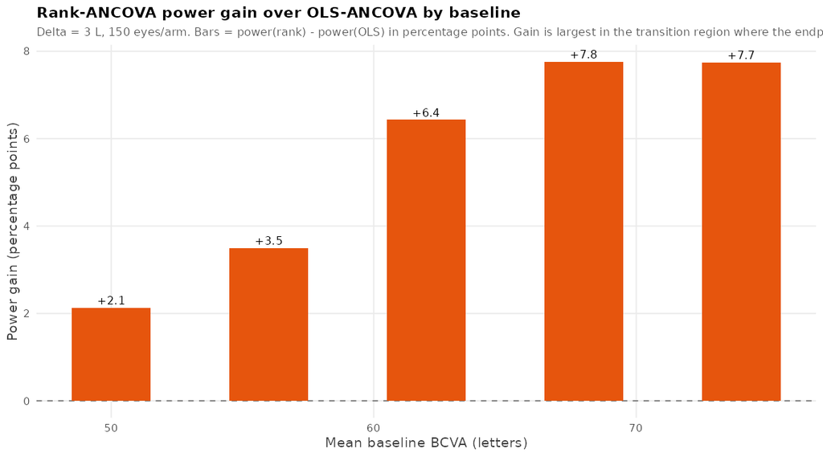

The practical addition to the endpoint rules is therefore: when the continuous endpoint is analysed, a **rank-based ANCOVA on the absolute endpoint (normal scores, approximating the proportional-odds model) is the robust default** — it matches the linear ANCOVA when the Normal assumption holds and beats it, at no Type-I cost, when the ceiling and skew make the response non-normal, which is the regime BCVA lives in. The linear ANCOVA remains a perfectly valid, transparent choice; the rank-based model is the assumption-lean insurance that also happens to recover power here.

### 8.3.8 Analysing the responder endpoint: odds ratio beats risk difference

If a $\ge15$-letter responder endpoint must be used, the **analysis scale** still matters. The risk-difference `prop.test` compares gainer *proportions* directly; as baseline rises both arms’ rates fall toward zero and the absolute gap they can produce shrinks with them, so power collapses — and it cannot adjust for baseline. The **odds ratio** from logistic regression tests the log-odds difference: at small base rates the same risk difference maps to a larger odds ratio, so the OR holds up better as headroom vanishes, and conditioning on baseline removes imbalance noise. Figure 27 shows the baseline-adjusted OR above the unadjusted OR, both above the risk-difference test, at every baseline. At baseline 62 the adjusted OR needs 270 eyes/arm against the risk-difference test’s 352 — a ~23% saving purely from the analysis choice.

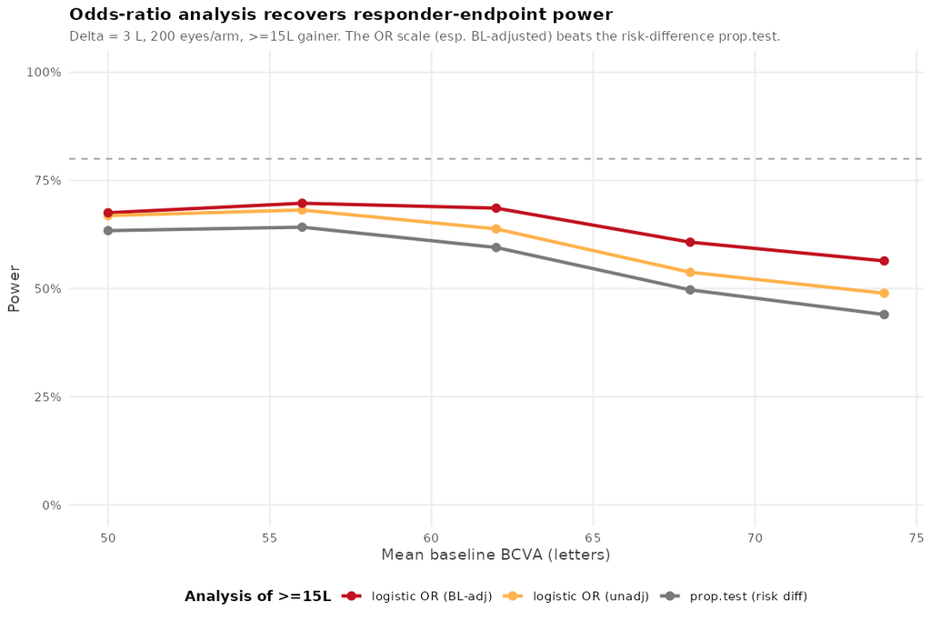

Figure 27: Analysing the >=15-letter responder endpoint: power vs baseline at Delta=3 L, 200 eyes/arm. The baseline-adjusted odds ratio (red) beats the unadjusted odds ratio (amber), which beats the risk-difference prop.test (grey). The gap widens with baseline as gainer rates fall.

The rule that follows is to analyse a responder endpoint on the **odds scale** (logistic regression or CMH), baseline-adjusted, not as a two-proportion risk-difference test — especially in higher-baseline populations. The caveat is that no scale rescues a population with no headroom: as the gainer rate approaches zero in both arms, counts become sparse and the odds-ratio estimate itself turns unstable (wide intervals, separation). The odds ratio beats the risk difference across the realistic range, but where almost no gainers are possible the continuous endpoint (Section 8.1) is the only efficient choice.

### 8.3.9 The simulated penalty against the analytic ARE anchors

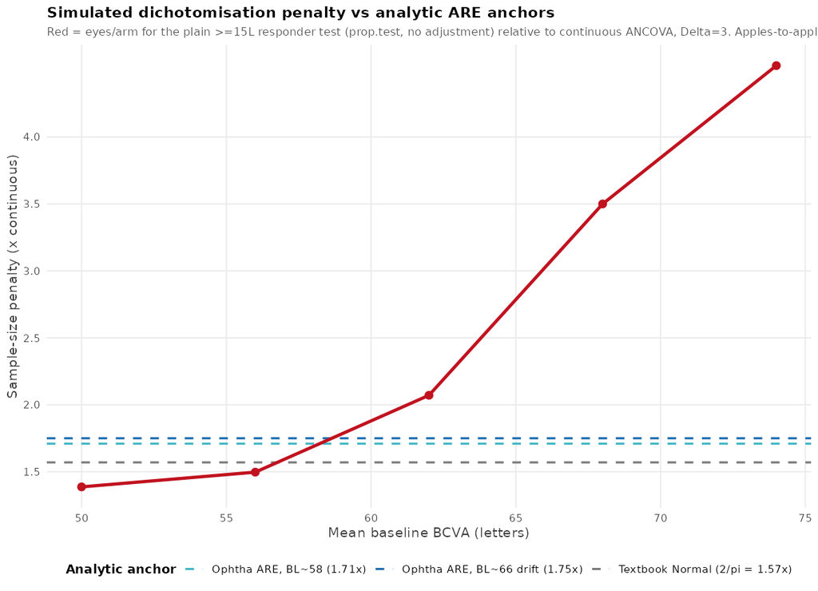

### 8.3.10 The endpoint hierarchy at a glance

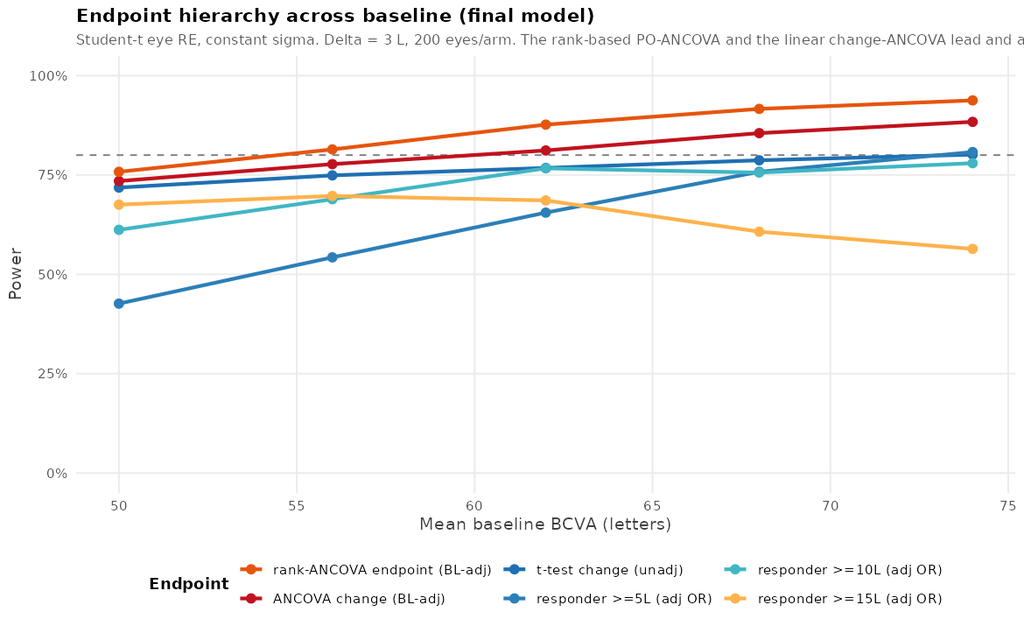

### 8.3.11 Eyes per arm by analysis, baseline, and effect

| Analysis (Delta=5 L) | BL 50 | BL 56 | BL 62 | BL 68 | BL 74 |
| --- | --- | --- | --- | --- | --- |
| t-test change | 83 | 74 | 71 | 70 | 68 |
| ANCOVA change | 79 | 69 | 65 | 57 | 53 |
| ANCOVA endpoint | 79 | 69 | 65 | 57 | 53 |
| Wilcoxon change | 73 | 68 | 63 | 63 | 60 |
| t-test endpoint | 130 | 120 | 105 | 91 | 78 |
| prop.test >=15L | 104 | 93 | 103 | 131 | 145 |
| logistic OR >=15L | 94 | 86 | 93 | 116 | 130 |
| logistic OR (BL-adj) >=15L | 94 | 81 | 82 | 100 | 101 |

## 8.4 Assumption-free robustness check: a nonparametric bootstrap

Every number in Section 8.3 rides on one modelling choice: that the data-generating process *is* the selected LogitNormal conditional-ANCOVA with a Student-$t$ eye random effect and a constant residual SD. That engine was chosen carefully (Section 7.8) and its Type-I error is exact by construction (Section 8.3.2) — but a parametric generator can only ever confirm the design numbers *conditional on its own functional form*. The question this subsection answers is the complementary one: **if we throw away the generator entirely and let the observed eyes speak for themselves, do the same conclusions hold?**

The tool is a **nonparametric cluster bootstrap** that reuses the real patient-level responses instead of simulating them. It shares the sweep’s grid, its analysis methods and its target-effect calibration, but replaces the fitted model with resampling. (The bootstrap check predates the rank-based ANCOVA of Section 8.3.7 and so covers the original 14 methods; since it exists to stress-test the *generator* rather than to rank analyses, and the rank ANCOVA behaves like the linear ANCOVA it closely tracks, re-running it for the 15th method would not change the assumption-robustness conclusion.) Where the two approaches agree, the design numbers are a property of the *data*, not of the LogitNormal assumption; where they disagree, the gap localises exactly which cells lean on the parametric form.

### 8.4.1 How the bootstrap is built

The resampling universe is the **aflibercept active-comparator reference** (RHINE + YOSEMITE, M12, one $(\text{BL},\text{DV})$ pair per eye, $n=541$ eyes, mean baseline 62.1 L, observed $\ge15$-letter gainer rate 0.320). Deliberately **not** the raw pool of all drugs: pooling heterogeneous compounds would inflate the resampling variance with a between-drug mixture component that no single trial arm ever sees, biasing power downward. The single well-characterised aflibercept reference is the honest cluster to bootstrap from — the same arm the parametric engine calibrates to.

Three devices carry the sweep’s scenario structure into the resampling world:

1. **Baseline reweighting to hit each scenario mean.** A trial “at baseline mean 56” is not the raw aflibercept sample (mean 62). Each eye is given a weight $w_i \propto f_{\text{target}}(\text{BL}_i)/f_{\text{emp}}(\text{BL}_i)$, the ratio of the target baseline density (the fitted truncated skew-normal of Section 15, its location shifted to the scenario mean) to the empirical baseline density. Weighted resampling then draws eyes so the resampled baseline distribution matches the scenario. Weights are capped at $30\times$ the median to stop a handful of extreme-baseline eyes dominating, and the effective sample size $\text{ESS}=(\sum w)^2/\sum w^2$ is recorded per cell.
2. **The treatment effect as a logit shift, root-found per cell.** To impose a target $\Delta$-letter superiority increment, the treatment arm’s responses are shifted on the **logit scale** by $\delta^\star$, where $\delta^\star$ is solved (`uniroot`) so the mean letter difference between the shifted treatment resample and the control resample equals the swept $\Delta$ at that scenario baseline. This is the nonparametric analogue of the engine’s per-eye Jacobian mapping — control eyes are the reference, treatment eyes are `plogis(qlogis(DV/100) +`$\delta^\star$`)` — and it keeps the realised letter effect on the same axis as the parametric sweep.
3. **Independent weighted resamples per arm.** Each trial draws the control arm ($\delta=0$) and the treatment arm ($\delta^\star$) as independent weight-proportional samples of $N$ eyes with replacement, then hands both to the identical 14-method analysis block copied verbatim from `21_s8_sweep.R`. Power is the rejection rate over 3000 bootstrap trials per cell.

The sweep covers baseline means $\{50,56,62,68,70\}$ × the same six effects × eight sample sizes, 3000 trials per cell, and writes `results/s8_power_grid_boot.csv` with two extra columns per cell — the **realised** baseline mean and the **ESS%** — that diagnose how far the reweighting had to stretch the sample. The generator runs on the sHPC where the clinical data live; only the aggregated power grid returns to Ona. Code: `shpc_s8_bootstrap.R` (remote) and `24_s8_boot_compare.R` (overlay + discrepancy).

### 8.4.3 The two approaches agree on the headline endpoints

Figure 30 overlays the parametric and bootstrap power-vs-$N$ curves for the representative endpoints at $\Delta=3$ L across the honest band. For the **continuous methods — the primary endpoints — the curves are nearly indistinguishable**: over the 2016 honest-band cells the baseline-adjusted ANCOVA on change has a mean absolute power discrepancy of **2.9 percentage points** (max 14.1), and the unadjusted change $t$-test **2.7 pp** (max 13.4). An assumption-free resampling of the real eyes reproduces the parametric power curve for the headline analyses to within Monte-Carlo-scale error. The endpoint *hierarchy* of Section 8.3.3 — adjusted continuous best, unadjusted change close behind, responder endpoints well below — is reproduced intact by the bootstrap.

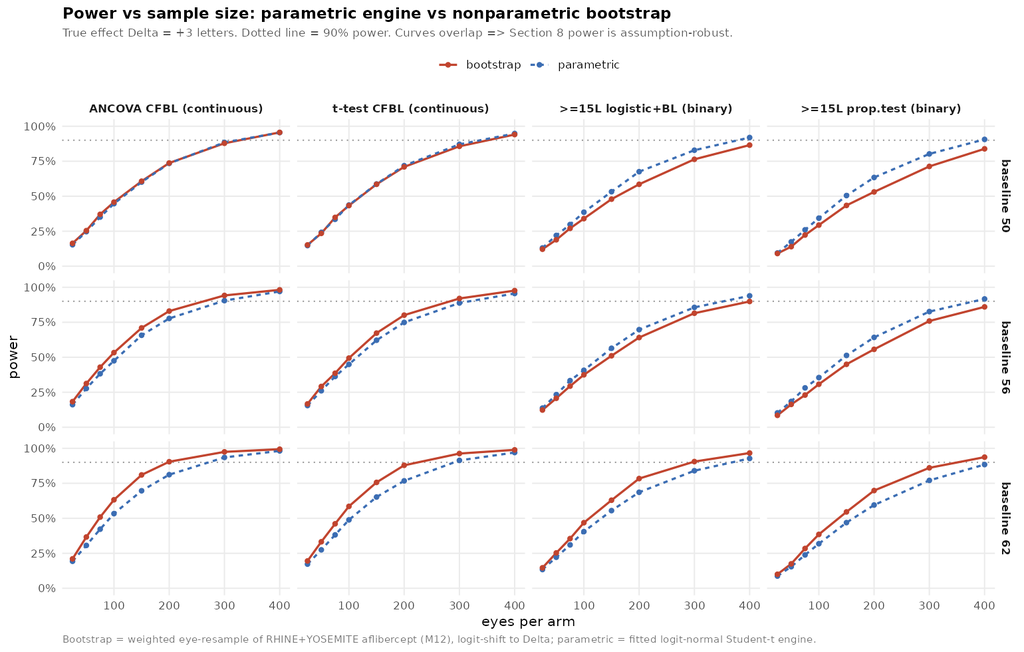

Type-I error is again controlled: Figure 31 shows the $\Delta=0$ bootstrap slice sitting on the nominal 5% for the continuous methods (median 0.050–0.055), with the same mild `prop.test` conservatism at the low thresholds seen in the parametric sweep (Section 8.3.2) — and for the same reason (discreteness of sparse gainer counts), which is a property of the *test*, not the generator, so both approaches show it identically.

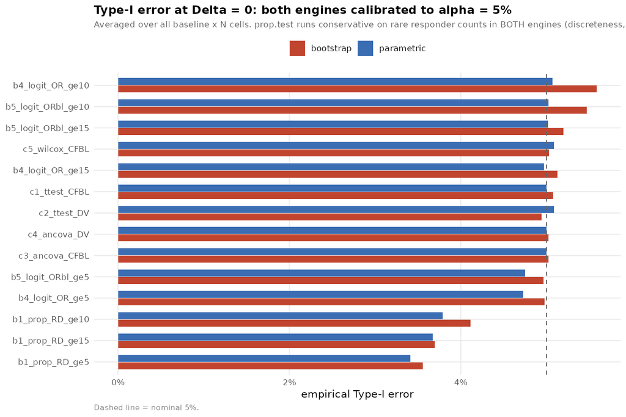

Figure 31: Type-I error at Delta=0, bootstrap vs parametric, all 14 analyses (median over honest-band baseline x N cells, nsim=3000). Both engines hold the nominal 0.05; the prop.test risk-difference at the low thresholds is mildly conservative under both, a discreteness property of the test rather than of the generator.

### 8.4.4 Where they differ, and why it strengthens the message

The discrepancy is not uniform. Figure 32 maps the absolute power gap by method and scenario, and the per-method summary (`results/s8_boot_discrepancy.csv`) ranks it. The pattern is clean:

Bootstrap-vs-parametric power discrepancy by analysis (all 2688 common-support cells, means 50-68). |Δpow| is the absolute power gap; median Δpow is signed (bootstrap minus parametric). Continuous methods agree closely; binary responder methods carry the largest gaps, concentrated in the mid-power transition region, where the bootstrap gives lower power (negative median).

| Analysis | Family | mean \|Δpow\| | max \|Δpow\| | median Δpow |
| --- | --- | --- | --- | --- |
| logistic OR >=10L | binary | 0.042 | 0.273 | -0.009 |
| prop.test >=10L | binary | 0.043 | 0.268 | -0.011 |
| logistic OR (BL-adj) >=15L | binary | 0.043 | 0.248 | +0.002 |
| logistic OR (BL-adj) >=10L | binary | 0.045 | 0.300 | -0.010 |
| logistic OR >=15L | binary | 0.051 | 0.283 | +0.003 |
| prop.test >=5L | binary | 0.052 | 0.336 | -0.003 |
| prop.test >=15L | binary | 0.053 | 0.312 | +0.002 |
| logistic OR >=5L | binary | 0.056 | 0.332 | -0.005 |
| logistic OR (BL-adj) >=5L | binary | 0.060 | 0.356 | -0.008 |
| ANCOVA change (adj) | continuous | 0.033 | 0.141 | +0.015 |
| ANCOVA endpoint (adj) | continuous | 0.033 | 0.141 | +0.015 |
| t-test change | continuous | 0.035 | 0.174 | +0.012 |
| Wilcoxon change | continuous | 0.047 | 0.205 | +0.019 |
| t-test endpoint | continuous | 0.054 | 0.165 | +0.045 |

- **It is concentrated in the mid-power transition region** — target baseline 62, the smallest non-null effect $\Delta=2$ L, and large $N$ (300–400). This is the steep part of the power curve, where a small shift in the responder-rate distribution moves power a lot. Away from the transition (small $N$, or $\Delta\ge4$, where power is near 0 or near 1) the two approaches agree tightly for binary methods too.
- **The bootstrap gives *lower* power there** (median $\Delta$pow is negative for the worst methods; e.g. the baseline-adjusted OR at $\ge10$ L reads 0.72 parametric vs 0.44 bootstrap in the extreme cell). The reason is structural: the smooth LogitNormal generates a clean, unimodal responder-rate distribution, whereas the real CFBL distribution is lumpier and heavier-tailed, so the empirical dichotomy splits less cleanly and the threshold tests lose power. The parametric engine is, if anything, **mildly optimistic about the binary endpoints** in exactly the region where dichotomisation is already known to be inefficient.

This does not weaken the section’s conclusions — it sharpens them. The **primary continuous endpoints are assumption-robust**: their design numbers survive discarding the model. And the **binary responder endpoints, which the parametric sweep already flagged as the costly choice (Section 8.3.4, Section 8.3.9), turn out to be *even costlier* under assumption-free resampling** in the small-effect regime — the bootstrap makes the case against dichotomisation stronger, not weaker.

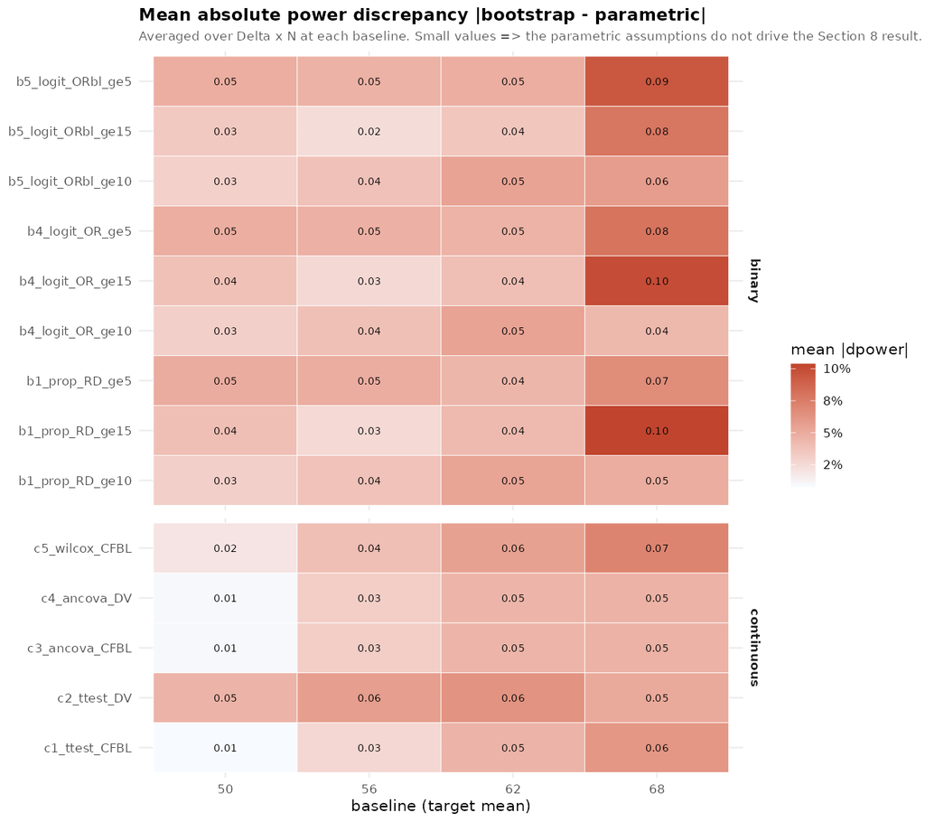

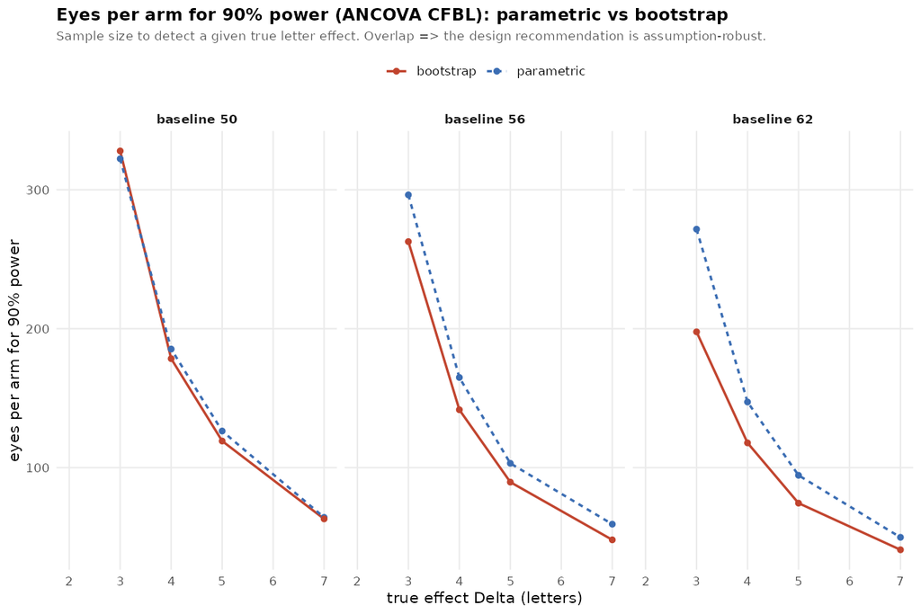

# 9 Data-quality note

Absolute BCVA (`DV`) equals exactly **0** in 79 records across several arms (HARBOR, RHINE, YOSEMITE). These are flagged (`qc_bcva_zero`) and **retained** for now. Before finalising the endpoint dataset, confirm whether they are genuine severe-vision-loss observations or imputed/error codes. These records also contribute to the heavy lower tail visible in the absolute-BCVA QQ plots (Section 4).

# 10 Next steps: from preview to confirmatory sweep

*Part (iv) of the design objective (Section 8).* The generator is selected and its fitness assessed (**LogitNormal**, Section 7.3), the baseline distribution fitted (Section 15), and the power / Type-I sweep run for DME across baseline × effect × N with the selected engine, analysed by 15 methods (Section 8.3). The efficiency trade-off is quantified against the analytic ARE anchors (Section 8.3.9): dichotomising the continuous response at $\ge15$ letters costs a 1.6–2.1× sample-size penalty at the reference baseline and grows to ~4.5× as the ceiling bites at high baseline (Section 8.3.5); baseline adjustment and the odds-ratio analysis each recover part of the loss (Section 8.3.6, Section 8.3.8); and a **rank-based (normal-scores) ANCOVA on the continuous endpoint is the single most efficient analysis** — 18% fewer eyes than the linear ANCOVA, at no Type-I cost (Section 8.3.7). What remains is to extend the confirmatory sweep.

1. **Propagate parameter uncertainty (Approach A).** The grid uses posterior-mean plug-in (Approach B) for point power. Re-run the headline cells with `posterior_predict` draws so the reported power carries **credible intervals** from the engine’s parameter uncertainty, not just Monte-Carlo trial error.
2. **Extend the sweep to nAMD and pooled.** The current grid is DME. nAMD has wider, higher baselines (Section 3) — repeat the sweep with the nAMD baseline generator and report the indication contrast in the sample-size table.
3. **Add the gainer odds-ratio scale to the headline.** Section 8.3 shows the ≥15L endpoint should be analysed on the **odds scale** (CMH/logistic), which partly recovers the ceiling penalty. Promote the OR analysis to the primary gainer row in any design recommendation.
4. **Store the simulation draws** from the selected model for the power / assurance work so scenarios are reproducible without re-fitting.
5. **A study-varying random-effect variance for assurance work.** The pooled generator reproduces the *typical* per-arm SD (pooled bias $-0.6\%$) but not its **between-study spread** — observed per-arm SD runs $\approx9$–$13$L across studies while the pooled $\tau$ prints a near-constant $\approx11$L (Section 7.6.2.2). This is by design for a pooled power sweep, but assurance-style and worst-case-arm questions need the spread. The correct lever is a **hierarchical, study-varying between-eye variance $\tau_{\text{STUDY}}$** — not the residual $\sigma\sim\text{STUDY}$ / $\sigma\sim\text{ns(BL)}$ law, which was tried and moved coverage negligibly because it acts on only $\approx12\%$ of the per-arm SD (Section 7.3.1, Section 14).
6. **Data reconciliation before any final run.** **READ3 verification** (confirmed baseline-mean outlier, excluded from the generators here) and the **79 `BCVA==0`** records — reconcile against the source before pooled or final-simulation use (Section 15, Section 9).

# 11 Appendix: brms priors and likelihood

Full specification of the full-Bayes (`brms` / Stan HMC) fits summarised in Section 6.2.7. All cells use the shared mean structure `Y ~ STUDY + post:ns(BL,4) + post:SARM + post:M12` with the rank-2 eye effect `(0 + phase | ID)` (Cholesky-parameterised $\Sigma$), sampled with 4 chains and, for the two scoring cells, the longer-warmup settings ITER = 5000 / WARMUP = 1500.

**Likelihoods (per family).** With $Y=$ absolute BCVA and $y=Y/100\in(0,1)$:

- **Gaussian (clamp):** $Y\sim\mathcal N(\mu,\sigma)$, identity link, predictive draws clamped to $[0,100]$.
- **Logit-normal:** $\operatorname{logit}(y)\sim\mathcal N(\mu,\sigma)$ — a Normal on the logit scale, so the response is bounded in $(0,100)$ by construction and the variance $\sigma$ is **decoupled** from the mean.
- **Skew-normal (clamp):** $Y\sim\text{SkewNormal}(\xi,\omega,\alpha)$, clamped; free skew $\alpha$ on top of a free scale.
- **Beta:** $y\sim\text{Beta}(\mu,\phi)$, logit link on $\mu$ — bounded but mean-locked variance $\mu(1-\mu)/(1+\phi)$.
- **Beta-binomial:** counts out of 100, logit link — bounded, discrete.

| Parameter class | Prior |
| --- | --- |
| Fixed effects $\beta$ (all `b`) | $\mathcal N(0,5)$ |
| Dispersion-model coefficients (`b`, dpar) | Student-$t_3(0,5)$ |
| Random-effect SDs $\tau_{\text{BL}},\tau_{\text{post}}$ (`sd`) | Student-$t_3(0,\,\cdot)$, half (positive) |
| RE correlation $\rho$ (`cor`, LKJ) | $\text{LKJ}(2)$ |
| Gaussian / logit-normal $\sigma$ | Student-$t_3(0,\,\cdot)$, half |
| Skew-normal skew $\alpha$ | $\mathcal N(0,4)$ |

The $\text{LKJ}(2)$ correlation prior is what regularises the near-singular $\Sigma$ that defeats the glmmTMB point estimator (Section 7.3.2): it gently pulls $\rho$ off the $\pm1$ boundary, which is why the brms rank-2 fit recovers an interior $\rho=0.63$ rather than collapsing to rank-1. The 1-RE cells drop the `cor` term and replace the $2\times2$ `sd` with a single scalar `sd`.

## 11.1 Per-cell convergence and coverage (all five families)

Sampler diagnostics and in-sample coverage for every brms cell fitted for Section 7.4. The shipped model (Logit-normal cANCOVA) is the row to read; the other cells document the family sweep behind the selection.

brms sampler diagnostics per cell. R-hat verdict: ‘clean’ <=1.01, ‘OK, low ESS’ 1.01-1.05, ‘FAIL’ >1.05. After the longer-warmup refit (ITER=5000, WARMUP=1500) the two scoring cells that were previously low-ESS are now clean with ample ESS (Logit-normal 1.002/ESS 686, SkewN 1.003/ESS 1033), joining Gaussian (1.006/ESS 423); SkewN-trunc is 1.010/ESS 336 (fit fine, predictive unscorable). Only Beta fails (1.98, ESS 6) and is not interpreted. SkewN-trunc’s fit is fine but its predictive cannot be sampled (brms trunc() posterior_predict bug), so it has no coverage row.

| cell | model | max R-hat | divergences | min ESS | fit (s) | verdict |
| --- | --- | --- | --- | --- | --- | --- |
| gau_re | Gaussian 2-RE (clamp) | 1.006 | 0 | 423 | 613 | clean |
| skn_re | SkewN 2-RE | 1.003 | 0 | 1033 | 2532 | clean |
| beta_re | Beta 2-RE | 1.980 | 0 | 6 | 1250 | FAIL (R-hat) |
| ln_re | LogitNormal 2-RE | 1.002 | 0 | 686 | 945 | clean |
| skn_trunc_re | SkewN-trunc 2-RE | 1.010 | 0 | 336 | 6504 | clean |
| ln_re1 | LogitNormal 1-RE | 1.010 | 0 | 413 | 183 | clean |
| gau_re1 | Gaussian 1-RE (clamp) | 1.012 | 0 | 527 | 126 | OK, low ESS |

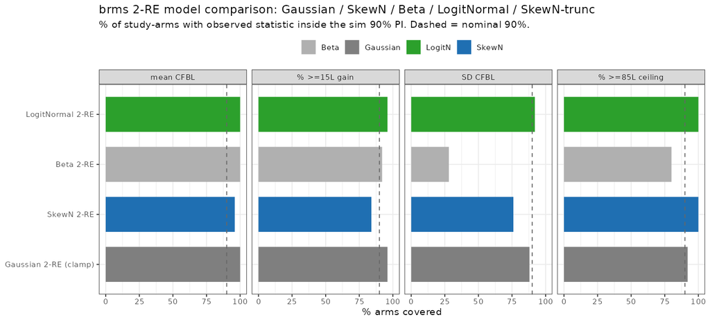

## 11.2 Fair post-only elpd-LOO grid (corroborating check for §7.5)

The production selection in Section 7.4 is made on the four-functional forward-conditional score, **not** on LOO. For completeness we *also* ran a fair information-criterion comparison across the full production grid, and it corroborates the scorecard: joint 2-RE and cANCOVA are statistically indistinguishable, and only the plain-Normal reference is rejected.

Raw LOOIC cannot be compared directly across these cells because they score different observation sets — the joint model’s likelihood covers the endpoint rows **and** the baseline rows, while cANCOVA covers **post rows only** (an earlier draft drew a false “cANCOVA fits far better” conclusion from exactly that mismatch). The fair comparison recomputes PSIS-LOO restricting the pointwise log-likelihood to the **common 8,362 post rows** for every cell:

Fair comparison: elpd restricted to the SAME 8,362 post rows for every cell (higher = better). On the common data joint and cANCOVA are statistically indistinguishable — Δelpd between the best joint and best cANCOVA cell is ~14 with a per-model SE of ~100. The plain-Normal reference is decisively rejected. p_loo ≈ 3,770 (~n/2) signals many high-influence points (one measurement per eye’s random intercept), so even this fair LOO is unreliable for a final decision and is NOT the deciding criterion — it is a corroborating check only.

| Model | n (post rows) | elpd | SE | Δelpd vs best | p_loo |
| --- | --- | --- | --- | --- | --- |
| Joint 2-RE, sigma~STUDY+ns(BL) | 8362 | -1409.6 | 100.8 | 0.0 | 3772 |
| cANCOVA, sigma~STUDY+ns(BL) | 8362 | -1423.5 | 101.2 | -13.9 | 3761 |
| Joint 2-RE, sigma~STUDY | 8362 | -1426.2 | 103.3 | -16.6 | 3771 |
| cANCOVA, sigma~STUDY | 8362 | -1429.7 | 103.3 | -20.1 | 3771 |
| cANCOVA, sigma=const | 8362 | -1511.8 | 115.5 | -102.2 | 3734 |
| Joint 2-RE, sigma=const | 8362 | -1516.4 | 115.8 | -106.8 | 3737 |
| Normal (letter scale) ref | 8362 | -26367.5 | 110.5 | -24957.9 | 3765 |

Two things follow. First, on the common data **joint ≈ cANCOVA** — the Δelpd of ~14 between the best joint and best cANCOVA cell is well within the ~100 per-model SE (consistent with Section 6.2.3: they are the same model in the $\tau_{\text{BL}}\to0$ limit). Second, **LOO is itself untrustworthy here** (`p_loo ≈ 3,770` against $n=8{,}362$ = the fingerprint of a per-eye random intercept with few points per eye), so we do not let it decide; only the plain-Normal reference (elpd ~$-26{,}000$) is safely rejected. This is why Section 7.4 selects on the four-functional score and treats this grid as corroboration.

# 12 Appendix: priors and full posterior of the final Student-$t$ eye-RE model

Complete prior and posterior specification for the shipped model of Section 7.7 — the constant-$\sigma$ **logit-normal cANCOVA with a genuine Student-$t$ eye random effect** (`shpc_fit_tRE_v2.R`). This is the model actually used by the Section 8 simulation engine, so its full parameter vector is recorded here. Note the priors differ from the family-sweep priors above (Section 11): the sweep used $\mathcal N(0,5)$ / Student-$t_3$ regularisers to keep every family fittable, whereas the final single-model fit uses the tighter $\mathcal N(0,3)$ / $\mathcal N(0,2)$ set below.

**Mean structure.** On the logit scale $\operatorname{logit}(Y/100)$:
$$\operatorname{logit}(y_{ij}) \;=\; \beta_0 \;+\; \text{STUDY}_i \;+\;
\text{ns}(BL_i,4)\,\boldsymbol\gamma \;+\; \text{SARM}_i \;+\; \beta_{M12}\,\mathbb 1[t=\text{M12}]
\;+\; u_j,$$
with one eye random intercept $u_j$ per eye $j$. `SARM = STUDY::ARM` nests `STUDY`, so the individual `STUDY`/`SARM` columns are **partially aliased** — see the note under the table.

**Priors (as set in the fit).**

| Parameter class | Prior |
| --- | --- |
| Population effects $\beta$ (intercept, STUDY, ns(BL,4), SARM, M12) | $\mathcal N(0,3)$ |
| Eye-RE scale $\text{sd}_1$ (the Student-$t$ *scale*) | $\mathcal N(0,2)$, half |
| Residual SD $\sigma$ | $\mathcal N(0,2)$, half |
| Eye-RE tail $\nu$ | $\text{Gamma}(2,\,0.1)$ |
| Standardised eye effects $z_j$ | $\text{Student-}t(\nu,0,1)$ (non-centred scale mixture) |

**Posterior — interpretable parameters.** Hyperparameters, intercept, baseline spline and the timepoint effect, all cleanly converged ($\hat R\le 1.02$):

Final Student-t eye-RE cANCOVA: posterior of the hyperparameters and interpretable fixed effects. nu=4.29 (heavy tail), t-scale sd_1=0.368 (marginal eye-RE SD = sd_1*sqrt(nu/(nu-2)) = 0.50 on the logit scale), residual sigma=0.211. The ns(BL,4) basis coefficients are the baseline-response spline; M12 is ~0 (month-9 and month-12 responses coincide on the logit scale). All ESS>700, R-hat<=1.02.

| Parameter | Prior | mean | SD | q5 | q95 | R-hat | ESS |
| --- | --- | --- | --- | --- | --- | --- | --- |
| nu | Gamma(2, 0.1) [on nu] | 4.292 | 0.315 | 3.804 | 4.834 | 1.012 | 1280 |
| sd_1 (eye RE t-scale) | Normal(0, 2), half [class sd] | 0.368 | 0.008 | 0.355 | 0.382 | 1.021 | 725 |
| sigma | Normal(0, 2), half [class sigma] | 0.211 | 0.002 | 0.207 | 0.215 | 1.001 | 5538 |
| Intercept | Normal(0, 3) [class b] | 0.804 | 0.007 | 0.792 | 0.815 | 1.003 | 2461 |
| M12 (month-12 vs month-9) | Normal(0, 3) [class b] | 0.002 | 0.005 | -0.006 | 0.009 | 1.000 | 26938 |
| ns(BL,4) basis 1 | Normal(0, 3) [class b] | 2.430 | 0.123 | 2.227 | 2.631 | 1.002 | 1546 |
| ns(BL,4) basis 2 | Normal(0, 3) [class b] | 2.195 | 0.082 | 2.061 | 2.329 | 1.003 | 1666 |
| ns(BL,4) basis 3 | Normal(0, 3) [class b] | 4.506 | 0.280 | 4.042 | 4.963 | 1.002 | 1567 |
| ns(BL,4) basis 4 | Normal(0, 3) [class b] | 2.390 | 0.092 | 2.241 | 2.543 | 1.001 | 2544 |

**Posterior — study and arm effects.** The `STUDY` and `SARM` coefficients are reported for completeness but are **individually uninterpretable**: because `SARM` nests `STUDY`, the design is rank-deficient and these columns are only identified up to a per-study additive shift. This shows in the posteriors as prior-dominated marginals (SD $\approx$ 1.3–1.7, i.e. the $\mathcal N(0,3)$ prior barely updated) with high ESS — the sampler is exploring the aliased null space, not learning individual arm means. What *is* identified is the fitted mean per study×arm (the sum of the relevant columns), which is what the simulation engine uses; the reference arm (pooled aflibercept) is reconstructed from these sums in `21_s8_sweep.R`.

Final Student-t eye-RE cANCOVA: STUDY and STUDY::ARM population effects. These are partially aliased (SARM nests STUDY): the wide, prior-dominated marginals (SD~1.3-1.7 against the N(0,3) prior) reflect the rank-deficient design’s null space, NOT genuine posterior uncertainty about a fitted mean. The identified quantities are the per-arm SUMS; R-hat<=1.01 throughout confirms the sampler mixed over the aliased directions cleanly.

| Parameter | mean | SD | q5 | q95 | R-hat | ESS |
| --- | --- | --- | --- | --- | --- | --- |
| arm AVENUE::RO68674611.5mgQ4W | 0.090 | 0.104 | -0.080 | 0.260 | 1.001 | 3498 |
| arm AVENUE::RO68674616mgQ4W | -0.064 | 0.104 | -0.233 | 0.107 | 1.000 | 3632 |
| arm AVENUE::RO68674616mgQ4WDQ8W | -0.068 | 0.094 | -0.222 | 0.085 | 1.001 | 4338 |
| arm AVENUE::Ranibizumab0.5mgQ4WRO68674616mgQ4W | -0.027 | 0.089 | -0.174 | 0.118 | 1.001 | 3843 |
| arm HARBOR::Ranibizumab0.5mgMonthly | 0.008 | 1.343 | -2.207 | 2.199 | 1.002 | 4654 |
| arm HARBOR::Ranibizumab0.5mgPRN | -0.028 | 1.343 | -2.234 | 2.176 | 1.002 | 4681 |
| arm HARBOR::Ranibizumab2.0mgMonthly | 0.040 | 1.344 | -2.168 | 2.229 | 1.002 | 4653 |
| arm HARBOR::Ranibizumab2.0mgPRN | -0.041 | 1.343 | -2.248 | 2.156 | 1.002 | 4655 |
| arm LUCERNE::ARMAM6MGIVTRO6867461 | 0.007 | 1.740 | -2.805 | 2.852 | 1.001 | 9021 |
| arm LUCERNE::ARMBM2MGIVTAFLIBERCEPT | -0.004 | 1.740 | -2.821 | 2.835 | 1.001 | 9012 |
| arm READ3::Ranibizumab0.5mgQ4W | -0.010 | 1.735 | -2.879 | 2.874 | 1.000 | 9127 |
| arm READ3::Ranibizumab2mgQ4W | -0.099 | 1.734 | -2.969 | 2.767 | 1.000 | 9098 |
| arm RHINE::ARMAM6MGIVTRO6867461 | 0.015 | 1.532 | -2.515 | 2.584 | 1.000 | 6272 |
| arm RHINE::ARMBM6MGIVTRO6867461PERSONALIZEDTREATMENTINTERVAL | -0.003 | 1.532 | -2.534 | 2.569 | 1.000 | 6278 |
| arm RHINE::ARMCM2MGIVTAFLIBERCEPT | -0.016 | 1.532 | -2.550 | 2.548 | 1.000 | 6280 |
| arm STAIRWAY::RO68674616mgQ12W | -0.046 | 1.304 | -2.186 | 2.113 | 1.000 | 5411 |
| arm STAIRWAY::RO68674616mgQ16W | 0.159 | 1.307 | -2.002 | 2.294 | 1.000 | 5407 |
| arm STAIRWAY::RO68674616mgQ16WDQ12W | 0.051 | 1.312 | -2.084 | 2.219 | 1.000 | 5397 |
| arm STAIRWAY::Ranibizumab0.5mgQ4W | -0.068 | 1.304 | -2.210 | 2.070 | 1.000 | 5436 |
| arm TENAYA::ARMAM6MGIVTRO6867461 | 0.017 | 1.718 | -2.805 | 2.846 | 1.000 | 8933 |
| arm TENAYA::ARMBM2MGIVTAFLIBERCEPT | -0.018 | 1.718 | -2.841 | 2.817 | 1.000 | 8931 |
| arm YOSEMITE::ARMAM6MGIVTRO6867461 | -0.009 | 1.479 | -2.410 | 2.478 | 1.001 | 6632 |
| arm YOSEMITE::ARMBM6MGIVTRO6867461PERSONALIZEDTREATMENTINTERVAL | 0.075 | 1.479 | -2.324 | 2.557 | 1.001 | 6629 |
| arm YOSEMITE::ARMCM2MGIVTAFLIBERCEPT | 0.009 | 1.478 | -2.391 | 2.500 | 1.001 | 6643 |
| STUDY = HARBOR | 0.019 | 1.344 | -2.183 | 2.238 | 1.002 | 4651 |
| STUDY = LUCERNE | -0.038 | 1.739 | -2.873 | 2.769 | 1.001 | 9059 |
| STUDY = READ3 | -0.103 | 1.736 | -2.982 | 2.773 | 1.000 | 9079 |
| STUDY = RHINE | 0.158 | 1.532 | -2.404 | 2.690 | 1.000 | 6283 |
| STUDY = STAIRWAY | 0.121 | 1.304 | -2.008 | 2.265 | 1.000 | 5394 |
| STUDY = TENAYA | -0.039 | 1.717 | -2.856 | 2.778 | 1.000 | 8968 |
| STUDY = YOSEMITE | 0.157 | 1.480 | -2.337 | 2.564 | 1.001 | 6631 |

# 13 Appendix: family verdict is structure-independent

The family comparison in Section 7.3 is run under the well-posed **cANCOVA** structure, where every family converges. This appendix confirms the verdict does not depend on that choice by repeating the two discriminating criteria under the **2-RE** structure. The 2-RE is deliberately *not* the main comparison because it is hard to converge for the unbounded family — the Gaussian rank-2 is near-degenerate ($\tau_{\text{BL}}\to0$, non-pdHess, Section 7.3.2) — so it cannot host a fair three-family screen; it can, however, confirm that the two bounded families still **tie** there.

Family verdict across structures, at the STUDY+ns(BL) dispersion law: cANCOVA (the main comparison) vs 2-RE, on the two discriminating criteria. Beta and Logit-normal are identical to each other under both structures. The Normal 2-RE cell did not converge (NA) — the reason the three-family screen is run under cANCOVA — whereas its cANCOVA counterpart does and still loses the ceiling. The family choice is structure-independent.

| Family | cANCOVA % >=85L | cANCOVA SD CFBL | 2-RE % >=85L | 2-RE SD CFBL |
| --- | --- | --- | --- | --- |
| Beta | 76 | 44 | 68 | 44 |
| Logit-normal | 76 | 44 | 68 | 44 |
| Normal | 40 | 48 |  |  |

Caveat: on the post-only rows `SARM` nests within `STUDY`, so the fixed-effect design is rank-deficient; `glmmTMB` drops the same redundant columns for **every** family, so the comparison stays fair (identical mean structure across families). This is a family-comparison check, not the structure decision — the cANCOVA-vs-2-RE *structure* question, on the selected Logit-normal engine, is settled in Section 7.3.

## 13.1 Family bias / coverage / Interval Score

Per-criterion decomposition behind the family verdict in Section 7.3 (cANCOVA, constant dispersion, forward-conditional): bias (sim median − observed), RMSE, coverage (target 90), mean interval width, and Interval Score (lower = better).

Family calibration by criterion (forward-conditional, cANCOVA, constant dispersion). Rows sorted within criterion by Interval Score. Constant sigma isolates the response scale (the axis that separates families) from the dispersion law (Section 7.5). The unbounded Normal is worst on the ceiling (large positive bias, low coverage, high Interval Score); Beta and Logit-normal are near-identical on every criterion. Skew-normal is brms-only and not in this glmmTMB prototype.

| Family | Criterion | bias | RMSE | coverage | width | IntervalScore |
| --- | --- | --- | --- | --- | --- | --- |
| Beta | mean CFBL | -0.22 | 0.36 | 100 | 3.89 | 3.89 |
| Normal | mean CFBL | 0.01 | 0.14 | 100 | 3.95 | 3.95 |
| Logit-normal | mean CFBL | -0.33 | 0.44 | 100 | 3.97 | 3.97 |
| Logit-normal | SD CFBL | -0.19 | 1.63 | 40 | 2.94 | 10.95 |
| Beta | SD CFBL | -0.35 | 1.69 | 44 | 2.88 | 11.67 |
| Normal | SD CFBL | -0.19 | 1.88 | 36 | 2.85 | 16.52 |
| Logit-normal | % >=15L gain | 0.06 | 3.99 | 88 | 15.31 | 17.37 |
| Beta | % >=15L gain | 0.17 | 3.78 | 88 | 15.43 | 17.95 |
| Normal | % >=15L gain | 0.38 | 4.17 | 80 | 15.70 | 21.57 |
| Logit-normal | % >=85L ceiling | 2.01 | 2.94 | 76 | 8.11 | 12.24 |
| Beta | % >=85L ceiling | 2.28 | 3.08 | 72 | 8.10 | 13.27 |
| Normal | % >=85L ceiling | 4.65 | 5.34 | 44 | 9.16 | 36.09 |

# 14 Appendix: the random-effect $\Delta$AIC screen

The grid selection in Section 7.3 reads the *forward-conditional* score, which is the metric the production simulator is judged on. This appendix provides the independent **likelihood** evidence that the per-eye random effect is real (not overfit): the RE-vs-marginal $\Delta$AIC, fitted across the four families at rank-1 vs marginal.

**AIC is comparable *within* a response scale, not across**

1. Normal and (N) Nils model absolute letters (`DV`); (b) Beta models the fraction $Y/100$; (bb) Beta-binomial models the letter count. Their likelihoods live on different scales, so the raw AIC column is only comparable **Normal vs Nils** (both letters). The **reff-vs-marginal $\Delta$AIC** *is* valid in every family — it adds/removes the random effect at a fixed response — and is the column to read for “does the RE help”.

| Model | variant | npar | logLik | AIC | BIC | converged |
| --- | --- | --- | --- | --- | --- | --- |
| (a) Normal spline | RE | 43 | -46045.3 | 92176.5 | 92497.5 | TRUE |
| (a) Normal spline | marginal | 41 | -48290.1 | 96662.2 | 96968.3 | TRUE |
| (b) Beta spline | RE | 43 | 13826.5 | -27566.9 | -27245.9 | TRUE |
| (b) Beta spline | marginal | 41 | 11365.6 | -22649.1 | -22343.0 | TRUE |
| (ln) Logit-normal | RE | 43 | -6618.1 | 13322.2 | 13643.2 | TRUE |
| (ln) Logit-normal | marginal | 41 | -9262.3 | 18606.6 | 18912.6 | TRUE |
| (bb) Beta-binomial | RE | 40 | -46641.7 | 93363.3 | 93661.9 | TRUE |
| (bb) Beta-binomial | marginal | 38 | -49077.1 | 98230.2 | 98513.9 | TRUE |
| (N) Nils quadratic | RE | 38 | -46921.6 | 93919.1 | 94202.8 | TRUE |
| (N) Nils quadratic | marginal | 36 | -49480.4 | 99032.9 | 99301.6 | TRUE |

| Family | AIC (RE) | AIC (marginal) | $\Delta$AIC (gain from RE) |
| --- | --- | --- | --- |
| (N) Nils quadratic | 93919.1 | 99032.9 | 5113.8 |
| (a) Normal spline | 92176.5 | 96662.2 | 4485.7 |
| (b) Beta spline | -27566.9 | -22649.1 | 4917.8 |
| (bb) Beta-binomial | 93363.3 | 98230.2 | 4866.9 |
| (ln) Logit-normal | 13322.2 | 18606.6 | 5284.4 |

Rank-1 loadings: baseline-level SD ($\tau_{\text{BL}}=|\lambda_{\text{BL}}|$), endpoint-level SD ($\tau_{\text{post}}=|\lambda_{\text{post}}|$), and their correlation $\rho=\pm1$ (structural: one shared factor). tau and dispersion are on each family’s link scale - the additive families (Normal, Nils) in letters, the bounded families (Beta, Beta-binomial) on logit. The Beta-binomial dispersion is astronomically large, the numerical signature of its collapse to the binomial-with-logit-RE limit.

| Family | $\tau_{\text{BL}}$ | $\tau_{\text{post}}$ | $\rho$ | disp (median) | link |
| --- | --- | --- | --- | --- | --- |
| (a) Normal spline | 0.454 | 8.648 | 1 | 5.345 | identity |
| (b) Beta spline | 0.007 | 0.430 | 1 | 74.530 | logit |
| (ln) Logit-normal | 0.005 | 0.448 | 1 | 0.245 | identity |
| (bb) Beta-binomial | 0.439 | 1.050 | 1 | 1684.335 | logit |
| (N) Nils quadratic | 10.940 | 29.004 | -1 | 4.100 | identity |

## 14.1 Dispersion-law AIC and why it does not drive selection

Section 7.3 shows the dispersion law is a secondary axis on the four scored functionals. The likelihood agrees once it is read on the model that ships — the **production cANCOVA form** (Logit-normal, post rows only, single random intercept), *not* the joint parametrization that also scores the baseline rows.

**The AIC gap depends entirely on which rows $\sigma$ is fit to**

The dispersion-law AIC comparison must be read on the **production cANCOVA** form, where the baseline enters as a *covariate* and $\sigma$ is estimated on endpoint rows only. A *joint* parametrization that also scores the ~4,540 baseline rows forces a single constant $\sigma$ to straddle the baseline and endpoint scales at once, badly inflating it and making the spline look essential ($\Delta\text{AIC}$ in the thousands). On the cANCOVA form that contamination is gone and the baseline-varying law’s advantage shrinks to a $\Delta\text{AIC}$ of about **177** (Section 14) — a secondary axis, consistent with the functional-based selection.

Dispersion-law AIC on the PRODUCTION cANCOVA form (Logit-normal, post rows only, (1|ID)). The baseline-varying law is still AIC-preferred, but by dAIC ~177 over constant sigma – not the ~5,000 gap of the contaminated joint fit. AIC rewards pointwise residual density, i.e. the within-eye ~12% variance component (see decomposition below) that the arm-level functionals barely see; it is therefore NOT the generator selector.

| Dispersion law | logLik | npar | AIC | dAIC |
| --- | --- | --- | --- | --- |
| constant (~1) | -4296.0 | 32 | 8655.9 | 177.2 |
| ~STUDY | -4230.6 | 39 | 8539.2 | 60.5 |
| ~STUDY+ns(BL) | -4197.3 | 42 | 8478.7 | 0.0 |

The per-arm SD functional the reader most expects the $\sigma$ law to help is dominated by the **between-eye** random effect, not the residual:

Variance decomposition of the per-arm CFBL SD, from the 3,822 eyes with both M9 and M12 (between-eye = SD of the eye mean; within-eye residual = SD of the M12-M9 difference / sqrt2). The between-eye factor carries ~88% of the variance; the residual sigma – the only part the dispersion law reshapes – carries ~12%. Even a +/-50% change in sigma moves the arm-level SD by only about -5%/+7%, which is why constant sigma is adequate for the scored functionals.

| Component | SD (letters) | Variance | Share (%) |
| --- | --- | --- | --- |
| between-eye (tau_post) | 11.03 | 121.6 | 87.8 |
| within-eye residual (sigma) | 4.10 | 16.8 | 12.2 |

Finally, the constant-$\sigma$ shape is not flat: the bounded Logit-normal link ($Y=100\,\text{plogis}(\eta)$, Jacobian $100\,p(1-p)$) makes a **constant** logit-scale $\sigma$ produce a letter-scale SD that already contracts with baseline ($\approx13.6$L at BL 45, $\approx5.8$L at BL 88), matching the observed 13.7 → 8.9 contraction across baseline tertiles (Section 5). The heteroscedasticity is real but mostly *ceiling geometry the family encodes for free* — an explicit $\sigma(BL)$ term is largely redundant with it. Net: constant $\sigma$ is the shipped default; the baseline-varying law is an optional refinement, not a selection driver.

# 15 Appendix: distribution fitting

Supporting detail for Section 3.1 (baseline) and Section 4.4 (endpoints).

## 15.1 Baseline support and truncation bounds

Baseline BCVA support per study (HARBOR BL=3 outlier excluded). L,U for the bounded fits are min/max.

| STUDY | n | min | p5 | median | p95 | max |
| --- | --- | --- | --- | --- | --- | --- |
| AVENUE | 272 | 24 | 31.0 | 57 | 72.0 | 83 |
| HARBOR | 1094 | 15 | 29.0 | 56 | 71.0 | 78 |
| LUCERNE | 657 | 24 | 32.0 | 61 | 77.0 | 78 |
| READ3 | 136 | 1 | 9.2 | 28 | 43.2 | 61 |
| RHINE | 947 | 27 | 41.3 | 65 | 73.0 | 86 |
| STAIRWAY | 67 | 30 | 37.3 | 61 | 72.7 | 73 |
| TENAYA | 668 | 24 | 34.0 | 65 | 76.0 | 78 |
| YOSEMITE | 937 | 25 | 40.0 | 64 | 73.0 | 81 |

## 15.2 Goodness-of-fit ranking

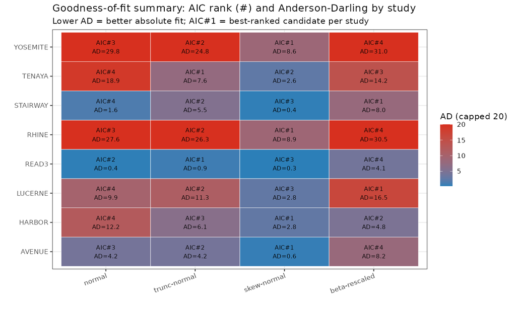

GoF summary: AIC rank (#, 1 = best) and Anderson-Darling A2 (colour, capped at 20) per study and distribution.

Full goodness-of-fit table, sorted by AIC within study.

| Study | Distribution | AIC | BIC | AD (A2) | AIC rank |
| --- | --- | --- | --- | --- | --- |
| AVENUE | skew-normal | 2095.1 | 2105.9 | 0.57 | 1 |
| AVENUE | trunc-normal | 2122.4 | 2129.6 | 4.25 | 2 |
| AVENUE | normal | 2134.1 | 2141.3 | 4.24 | 3 |
| AVENUE | beta-rescaled | 2168.9 | 2176.1 | 8.16 | 4 |
| HARBOR | skew-normal | 8507.9 | 8522.9 | 2.78 | 1 |
| HARBOR | beta-rescaled | 8558.9 | 8568.9 | 4.85 | 2 |
| HARBOR | trunc-normal | 8578.8 | 8588.8 | 6.12 | 3 |
| HARBOR | normal | 8675.6 | 8685.6 | 12.25 | 4 |
| LUCERNE | beta-rescaled | 5065.1 | 5074.1 | 16.50 | 1 |
| LUCERNE | trunc-normal | 5065.9 | 5074.9 | 11.32 | 2 |
| LUCERNE | skew-normal | 5118.0 | 5131.5 | 2.77 | 3 |
| LUCERNE | normal | 5294.3 | 5303.3 | 9.92 | 4 |
| READ3 | trunc-normal | 1041.0 | 1046.8 | 0.89 | 1 |
| READ3 | normal | 1043.8 | 1049.6 | 0.38 | 2 |
| READ3 | skew-normal | 1045.3 | 1054.1 | 0.29 | 3 |
| READ3 | beta-rescaled | 1087.3 | 1093.1 | 4.11 | 4 |
| RHINE | skew-normal | 6661.4 | 6676.0 | 8.91 | 1 |
| RHINE | trunc-normal | 6962.3 | 6972.0 | 26.26 | 2 |
| RHINE | normal | 6976.5 | 6986.2 | 27.61 | 3 |
| RHINE | beta-rescaled | 7042.1 | 7051.8 | 30.47 | 4 |
| STAIRWAY | beta-rescaled | 475.0 | 479.4 | 8.00 | 1 |
| STAIRWAY | trunc-normal | 483.5 | 487.9 | 5.50 | 2 |
| STAIRWAY | skew-normal | 491.2 | 497.8 | 0.42 | 3 |
| STAIRWAY | normal | 515.7 | 520.1 | 1.58 | 4 |
| TENAYA | trunc-normal | 5010.6 | 5019.6 | 7.64 | 1 |
| TENAYA | skew-normal | 5042.4 | 5055.9 | 2.61 | 2 |
| TENAYA | beta-rescaled | 5065.9 | 5074.9 | 14.23 | 3 |
| TENAYA | normal | 5286.8 | 5295.8 | 18.87 | 4 |
| YOSEMITE | skew-normal | 6572.4 | 6586.9 | 8.63 | 1 |
| YOSEMITE | trunc-normal | 6878.4 | 6888.1 | 24.82 | 2 |
| YOSEMITE | normal | 6948.9 | 6958.6 | 29.75 | 3 |
| YOSEMITE | beta-rescaled | 6961.3 | 6971.0 | 30.97 | 4 |

## 15.3 QQ and ECDF diagnostics

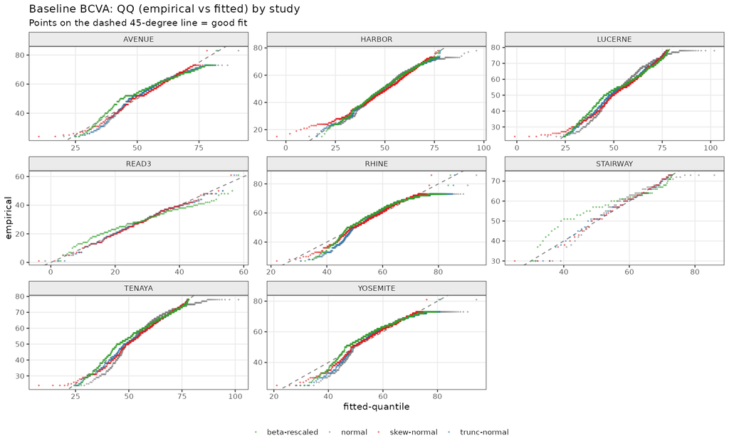

QQ plots (empirical vs fitted quantiles) per study. Points on the dashed 45 deg line indicate good fit.

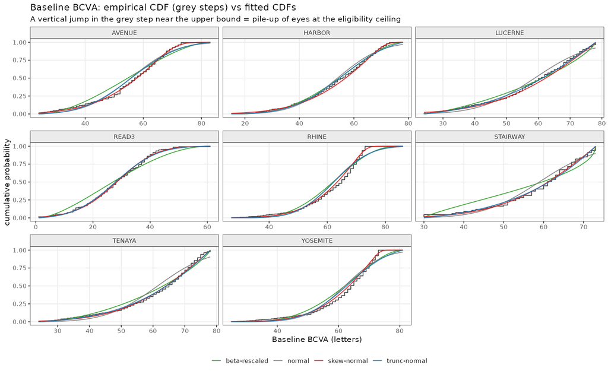

Empirical CDF (grey steps) vs fitted CDFs. A steep rise near the upper bound marks the near-ceiling build-up of eyes.

## 15.4 Near-ceiling concentration

Baseline concentration near the ceiling. Only 0.1-6% sit within 1 letter of the cap, but 25-32% lie in the 70-to-cap band in the high-baseline nAMD studies.

| Study | n | cap | % at cap (+/-1) | % >=70 | % <=30 |
| --- | --- | --- | --- | --- | --- |
| STAIRWAY | 67 | 73 | 6.0 | 16.4 | 4.5 |
| LUCERNE | 657 | 78 | 3.3 | 25.3 | 4.4 |
| TENAYA | 668 | 78 | 2.2 | 32.2 | 2.7 |
| READ3 | 136 | 61 | 0.7 | 0.0 | 57.4 |
| AVENUE | 272 | 83 | 0.4 | 9.6 | 4.8 |
| HARBOR | 1094 | 78 | 0.1 | 9.0 | 6.7 |
| RHINE | 947 | 86 | 0.1 | 25.3 | 0.7 |
| YOSEMITE | 937 | 81 | 0.1 | 25.3 | 1.2 |

## 15.5 Endpoint fits: GoF and QQ

Supporting detail for Section 4.4. Fits are per study x timepoint (M9, M12).

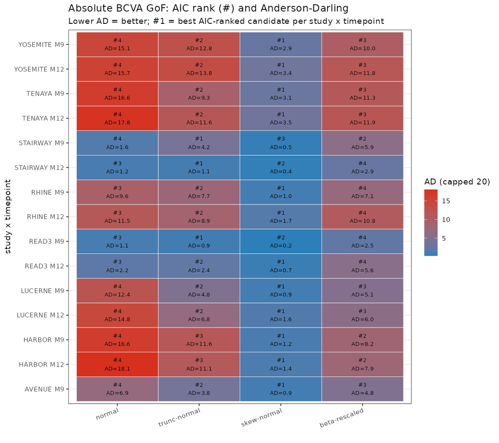

Absolute BCVA goodness-of-fit, sorted by AIC within study x timepoint.

| Study | TP | Distribution | AIC | BIC | AD (A2) | AIC rank |
| --- | --- | --- | --- | --- | --- | --- |
| AVENUE | M9 | skew-normal | 2048.6 | 2059.2 | 0.93 | 1 |
| AVENUE | M9 | trunc-normal | 2079.1 | 2086.2 | 3.83 | 2 |
| AVENUE | M9 | beta-rescaled | 2095.6 | 2102.7 | 4.85 | 3 |
| AVENUE | M9 | normal | 2123.0 | 2130.1 | 6.93 | 4 |
| HARBOR | M12 | skew-normal | 9071.1 | 9086.1 | 1.37 | 1 |
| HARBOR | M12 | beta-rescaled | 9206.9 | 9216.9 | 7.89 | 2 |
| HARBOR | M12 | trunc-normal | 9210.2 | 9220.2 | 11.09 | 3 |
| HARBOR | M12 | normal | 9301.8 | 9311.8 | 18.07 | 4 |
| HARBOR | M9 | skew-normal | 9008.8 | 9023.8 | 1.22 | 1 |
| HARBOR | M9 | beta-rescaled | 9151.8 | 9161.8 | 8.22 | 2 |
| HARBOR | M9 | trunc-normal | 9163.1 | 9173.1 | 11.57 | 3 |
| HARBOR | M9 | normal | 9226.5 | 9236.5 | 16.60 | 4 |
| LUCERNE | M12 | skew-normal | 4789.2 | 4802.3 | 1.57 | 1 |
| LUCERNE | M12 | trunc-normal | 4852.2 | 4860.9 | 6.78 | 2 |
| LUCERNE | M12 | beta-rescaled | 4863.2 | 4871.9 | 5.98 | 3 |
| LUCERNE | M12 | normal | 4971.4 | 4980.2 | 14.75 | 4 |
| LUCERNE | M9 | skew-normal | 4635.6 | 4648.7 | 0.94 | 1 |
| LUCERNE | M9 | trunc-normal | 4670.7 | 4679.4 | 4.76 | 2 |
| LUCERNE | M9 | beta-rescaled | 4686.6 | 4695.3 | 5.09 | 3 |
| LUCERNE | M9 | normal | 4789.0 | 4797.7 | 12.37 | 4 |
| READ3 | M12 | skew-normal | 948.3 | 956.7 | 0.65 | 1 |
| READ3 | M12 | trunc-normal | 956.5 | 962.0 | 2.44 | 2 |
| READ3 | M12 | normal | 965.9 | 971.4 | 2.22 | 3 |
| READ3 | M12 | beta-rescaled | 985.6 | 991.2 | 5.62 | 4 |
| READ3 | M9 | trunc-normal | 919.2 | 924.7 | 0.91 | 1 |
| READ3 | M9 | skew-normal | 922.4 | 930.7 | 0.24 | 2 |
| READ3 | M9 | normal | 931.8 | 937.3 | 1.09 | 3 |
| READ3 | M9 | beta-rescaled | 937.2 | 942.8 | 2.48 | 4 |
| RHINE | M12 | skew-normal | 6112.1 | 6126.2 | 1.71 | 1 |
| RHINE | M12 | trunc-normal | 6195.7 | 6205.2 | 8.93 | 2 |
| RHINE | M12 | normal | 6263.0 | 6272.4 | 11.48 | 3 |
| RHINE | M12 | beta-rescaled | 6307.6 | 6317.1 | 10.82 | 4 |
| RHINE | M9 | skew-normal | 6141.6 | 6155.8 | 0.98 | 1 |
| RHINE | M9 | trunc-normal | 6227.8 | 6237.2 | 7.65 | 2 |
| RHINE | M9 | normal | 6267.9 | 6277.4 | 9.58 | 3 |
| RHINE | M9 | beta-rescaled | 6310.2 | 6319.7 | 7.10 | 4 |
| STAIRWAY | M12 | trunc-normal | 457.0 | 461.1 | 1.05 | 1 |
| STAIRWAY | M12 | skew-normal | 461.9 | 468.1 | 0.41 | 2 |
| STAIRWAY | M12 | normal | 471.3 | 475.4 | 1.17 | 3 |
| STAIRWAY | M12 | beta-rescaled | 473.3 | 477.4 | 2.89 | 4 |
| STAIRWAY | M9 | trunc-normal | 471.0 | 475.3 | 4.18 | 1 |
| STAIRWAY | M9 | beta-rescaled | 471.6 | 475.8 | 5.91 | 2 |
| STAIRWAY | M9 | skew-normal | 475.6 | 482.0 | 0.47 | 3 |
| STAIRWAY | M9 | normal | 497.7 | 501.9 | 1.61 | 4 |
| TENAYA | M12 | skew-normal | 4680.8 | 4693.9 | 3.52 | 1 |
| TENAYA | M12 | trunc-normal | 4792.4 | 4801.2 | 11.64 | 2 |
| TENAYA | M12 | beta-rescaled | 4804.1 | 4812.8 | 11.92 | 3 |
| TENAYA | M12 | normal | 4875.1 | 4883.8 | 17.79 | 4 |
| TENAYA | M9 | skew-normal | 4613.1 | 4626.1 | 3.07 | 1 |
| TENAYA | M9 | trunc-normal | 4695.7 | 4704.4 | 9.28 | 2 |
| TENAYA | M9 | beta-rescaled | 4748.1 | 4756.8 | 11.34 | 3 |
| TENAYA | M9 | normal | 4809.9 | 4818.6 | 16.62 | 4 |
| YOSEMITE | M12 | skew-normal | 5970.9 | 5984.9 | 3.42 | 1 |
| YOSEMITE | M12 | trunc-normal | 6109.5 | 6118.9 | 13.83 | 2 |
| YOSEMITE | M12 | beta-rescaled | 6147.7 | 6157.0 | 11.79 | 3 |
| YOSEMITE | M12 | normal | 6155.8 | 6165.1 | 15.72 | 4 |
| YOSEMITE | M9 | skew-normal | 5988.6 | 6002.6 | 2.85 | 1 |
| YOSEMITE | M9 | trunc-normal | 6114.3 | 6123.7 | 12.78 | 2 |
| YOSEMITE | M9 | beta-rescaled | 6154.3 | 6163.6 | 10.02 | 3 |
| YOSEMITE | M9 | normal | 6160.9 | 6170.2 | 15.07 | 4 |

CFBL Anderson-Darling: normal vs skew-normal per study x timepoint (lower = better). Normal is adequate only in low-baseline studies.

| STUDY | TP | normal | skew-normal |
| --- | --- | --- | --- |
| AVENUE | M9 | 2.52 | 1.28 |
| HARBOR | M12 | 4.30 | 3.07 |
| HARBOR | M9 | 3.68 | 2.90 |
| LUCERNE | M12 | 7.48 | 5.28 |
| LUCERNE | M9 | 3.87 | 3.33 |
| READ3 | M12 | 0.49 | 0.52 |
| READ3 | M9 | 0.34 | 0.34 |
| RHINE | M12 | 8.65 |  |
| RHINE | M9 | 4.15 | 4.23 |
| STAIRWAY | M12 | 0.40 | 0.34 |
| STAIRWAY | M9 | 0.40 | 0.37 |
| TENAYA | M12 | 8.38 | 4.69 |
| TENAYA | M9 | 6.40 | 4.34 |
| YOSEMITE | M12 | 6.59 | 5.42 |
| YOSEMITE | M9 | 3.93 |  |

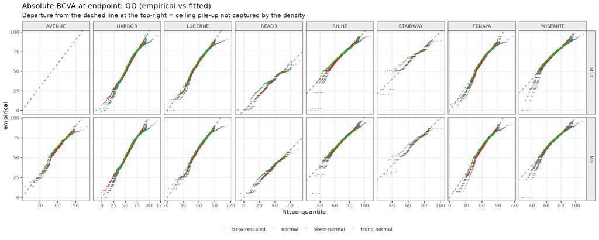

Absolute BCVA QQ (empirical vs fitted) per study x timepoint. Departure at the top-right marks ceiling pile-up the density does not capture.

Percentage of eyes at >=85 letters (within 15 of the 100 cap) by phase. Near zero at baseline; grows to 10-13% by endpoint in high-baseline nAMD.

| STUDY | Baseline | M12 | M9 |
| --- | --- | --- | --- |
| AVENUE | 0.0 |  | 0.8 |
| HARBOR | 0.0 | 4.3 | 3.6 |
| LUCERNE | 0.0 | 5.8 | 4.2 |
| READ3 | 0.0 | 0.0 | 0.0 |
| RHINE | 0.1 | 12.0 | 9.6 |
| STAIRWAY | 0.0 | 8.6 | 8.1 |
| TENAYA | 0.0 | 6.0 | 5.7 |
| YOSEMITE | 0.0 | 12.7 | 11.7 |

**Warning**

**READ3 baseline verification.** READ3 is investigator-led and non-registrational; its baseline BCVA distribution in this integrated dataset does not match the published READ3 report - possibly a coding issue. **TODO:** verify against the source before any pooled or final-simulation use. Retained and fit separately for now.

# 16 Appendix: frequentist vs full-Bayes — where the engine matters

The shipped cell (Logit-normal cANCOVA, constant $\sigma$) is fit by **both** glmmTMB (ML) and brms (HMC) on the identical `qlogis(Y/100)` response (Section 6.2.7). They differ only in estimation, so it is worth recording where that difference matters and where it does not — the summary in Section 7.5.1 reports the headline; this appendix gives the numbers.

**On the shipped cANCOVA cell: negligible.** Same response, same mean/RE structure, and the random intercept dominates the variance ($\approx88\%$ between-eye vs $12\%$ residual, Section 14), which ML identifies cleanly — so the posterior sits on the likelihood and ML lands in the same place.

| LogitN cANCOVA, const $\sigma$ | mean cov | SD cov | gainer cov | ceiling cov | mean bias (L) | SD ratio |
| --- | --- | --- | --- | --- | --- | --- |
| **glmmTMB (ML)** | 100 | 40 | 88 | 76 | −0.30 | 1.00 |
| **brms (HMC)** | 100 | 40 | 96 | 80 | −0.07 | 1.00 |

**On the 2-RE cell: the engines genuinely diverge — which is why that cell is fit in brms.** The free cross-correlation $\rho$ is weakly identified with one baseline point per eye, and here ML and HMC part ways:

| 2-RE (logit scale) | $\tau_{\text{BL}}$ | $\tau_{\text{post}}$ | $\rho$ |
| --- | --- | --- | --- |
| **glmmTMB (ML)** | 0.005 (collapses) | 0.45 | $\pm1$ (rank-1, structural) |
| **brms (HMC)** | 0.46 | 0.61 | 0.63 (free, identified) |

ML drives $\tau_{\text{BL}}\to0$ and pins $\rho=\pm1$ (the rank-1 degeneracy of Section 7.3.2); the priors in brms regularise the $2\times2$ covariance enough to recover a well-posed $\rho=0.63$. This is the one place the Bayesian fit buys something ML cannot deliver — and it is **confined to the 2-RE parametrization**, which the design needs only when the baseline is unobserved. On the shipped cANCOVA cell, where the baseline is a fixed covariate rather than a second random effect, the identification problem disappears and the two engines coincide — so the shipped model is fit in glmmTMB and brms is kept as the full-Bayes cross-check.

# 17 Appendix: why the naive +3L gainer *lift* rises with baseline

In Section 8.2.2.2 (Panel G) the two arms move in opposite directions: the **realistic** +3L lift *falls* with baseline (12.2 → 10.4 pp) while the **naive** +3L lift *rises* (9.5 → 13.9 pp). The realistic case is the intuitive one — near the ceiling there is less headroom, the drug’s letter effect shrinks, fewer eyes gain. The naive case looks backwards at first glance. This appendix explains it; it is deferred here because the mechanism, while important for reading Panel G honestly, would interrupt the main argument.

**First, separate two quantities that are easy to conflate.** The gainer *rate* is the share of eyes in **one arm** that gain ≥15 L. The *lift* is the **difference** between the treatment and control rates — the extra gainers the drug creates, and what Panel G actually plots. These behave differently with baseline:

| Baseline | Control rate | Naive-treated rate | **Naive lift (difference)** |
| --- | --- | --- | --- |
| 50 | 50.5% | 60.1% | **9.5 pp** |
| 60 | 41.2% | 52.5% | **11.4 pp** |
| 70 | 22.5% | 36.4% | **13.9 pp** |

The first two columns match the intuition exactly: **the rate falls with baseline in both arms** (there is less room to gain 15 letters when you start higher). So “higher baseline → fewer gainers” is true and is fully in the model. The puzzle is only in the third column — why the *difference* grows — and it is a different question: not “how many eyes gain?” but “how many extra eyes does the flat +3 L push over the line?”

**What the naive lift measures.** A flat +3-letter drug turns an eye into a ≥15 L gainer only if that eye was already within 3 letters of the threshold:
$$Y_{\text{ctrl}} + 3 \;\ge\; \text{BL}+15
\quad\Longleftrightarrow\quad
Y_{\text{ctrl}} \;\ge\; \text{BL}+12 .$$
So the lift is exactly the fraction of control eyes sitting in the fixed 3-letter window $[\text{BL}+12,\ \text{BL}+15]$ — the eyes close enough to be nudged across. Nothing else about the distribution matters: only **how many eyes are parked in that 3-letter strip just below the line.**

**Why more eyes are parked there at high baseline — the “denser slice.”** Figure 34 plots the control outcome distribution (in letters) at a low and a high baseline, with that 3-letter window shaded. At **low baseline** the outcome is broad (SD ≈ 11.7 L): the eyes are spread thinly across many letters, so a 3-letter strip catches only a thin sliver (9.5%). At **high baseline** the ceiling compresses *and* left-skews the outcome into a tall, narrow pile near the cap (SD ≈ 9.0 L): the +15 L threshold sits right in that pile-up, so the **same 3-letter-wide** window now covers a dense crowd of eyes (13.9%). Same window width, more eyes per letter — a denser slice.

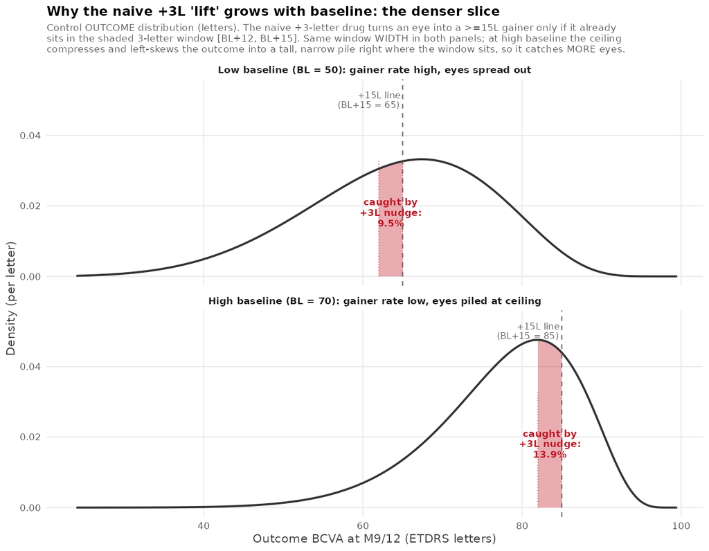

Figure 34: The ‘denser slice’ behind the rising naive lift. Each panel is the control OUTCOME distribution (letters) at a given baseline; the shaded band is the 3-letter window [BL+12, BL+15] within which a flat +3-letter drug converts an eye into a >=15L gainer. The window WIDTH is identical in both panels. At low baseline (top) the distribution is broad, so the window catches a thin 9.5% slice. At high baseline (bottom) the ceiling compresses and left-skews the outcome into a tall narrow pile right where the window sits, so the same window catches 13.9%. This is why the NAIVE lift RISES with baseline even though the gainer RATE falls; it is an artefact of the ceiling-blind flat-3L assumption. The realistic (logit) arm removes this artefact - its letter effect shrinks near the ceiling, so its lift falls, as intuition expects. Fitted logit-normal engine, analytic.

**Why this is a symptom of the naive assumption, not a real gain.** The naive arm *insists* the drug still delivers a full 3 letters at BL70 — the 78 → 81 that the ceiling makes impossible. Near the ceiling there happens to be a dense pile of eyes waiting just below the line for exactly that nudge, so the flat model hands the drug a growing “reward” for pretending the ceiling isn’t there. The realistic logit model removes the reward: the same drug buys only ~2.6 L at BL70, its effect can’t reach as far, and its lift falls with baseline — the behaviour intuition expects. So the rising naive lift does not contradict “higher baseline is harder”; it is the fingerprint of the ceiling-blind assumption, and the reason the realistic scale is the honest one to design against.

# 18 Appendix: how the rank ANCOVA relates to the proportional-odds model

The main text (Section 8.3.7) introduces the sixth continuous analysis — the normal-scores rank ANCOVA, `c6` — as “Harrell’s fast, close approximation to the proportional-odds model.” That sentence does a lot of quiet work. This appendix unpacks it: *why* a rank analysis is a proportional-odds analysis, what the single number it estimates actually means, and why that meaning is the right one for a ceiling-bound BCVA endpoint. It is deferred here because the correspondence, while it is the theoretical justification for carrying `c6` at all, is not needed to read the power curves.

## 18.1 The proportional-odds model in one line

Take the endpoint $Y$ and treat its *ordering* as the only thing that is real — every distinct letter value is a category, ranked worst to best. The **proportional-odds** (PO) model, the ordinal-logistic cumulative model, writes for every possible cutpoint $y$

$$\operatorname{logit}\,\Pr(Y \le y \mid \text{arm}, \text{BL})
\;=\; \alpha_y \;-\; \beta\,\text{arm} \;-\; \gamma\,\text{BL}.$$

There is a separate intercept $\alpha_y$ for **every** cutpoint — so the model makes no assumption whatever about the *shape* of the outcome distribution; the $\alpha_y$ absorb it, ceiling and skew included. What is assumed is the single word in the model’s name: the arm effect $\beta$ is **one** number, the same log-odds ratio at every cutpoint $y$. The drug is posited to shift the whole cumulative distribution by a constant amount *on the log-odds scale*, whether you slice the outcome at +5 letters, at +15, or at any other line. That single $\beta$ is the treatment effect the PO model reports, and $\exp(\beta)$ is its **odds ratio**.

## 18.2 Why a rank test *is* the score test of that model

The link to ranks is not an analogy; it is an identity. The efficient **score test** of $\beta = 0$ in the two-group proportional-odds model is *algebraically the Wilcoxon–Mann–Whitney rank-sum test* (its many-group generalisation is the Kruskal–Wallis test). Testing “is the treatment log-odds ratio zero?” in the PO model and running a Wilcoxon test on the raw endpoint are the **same computation** — the rank test is what the ordinal likelihood reduces to at the null. So the moment you analyse the endpoint by its ranks, you are already inside the proportional-odds world; you have simply run its score test rather than fitting its full likelihood.

`c6` adds the two refinements that turn that bare rank test into a usable ANCOVA:

1. **Normal (van der Waerden) scores instead of the raw ranks.** Each rank $R$ is mapped through the inverse normal CDF, $z = \Phi^{-1}\!\big((R-\tfrac38)/(n+\tfrac14)\big)$, before it enters the linear model (Section 8.3.7). This is the *normal-scores* member of the rank-test family; it is asymptotically fully efficient and, on a continuous latent scale, tracks the PO likelihood more tightly than the flat Wilcoxon weights while remaining a pure monotone function of the ranks. Harrell’s recommendation to use it as a fast PO surrogate is exactly this: it reproduces the power and Type-I of a full `polr` fit to within Monte-Carlo error at a fraction of the cost, which is why the sweep carries the scored form rather than the iterative ordinal likelihood (Section 8.3.7).
2. **Baseline as a raw, free covariate.** The transform is applied to the *response only*; baseline BCVA enters the right-hand side untransformed, with a freely estimated slope (Section 8.3.7). This is the “ANCOVA” half — it conditions on baseline to strip the between-eye variance that would otherwise dilute the arm contrast, without forcing the unit-slope change-score constraint the main text warns against.

The result is an analysis that is a proportional-odds test in its inferential content and an ordinary least-squares fit in its cost.

## 18.3 What the odds ratio *means* here

The PO odds ratio has a concrete, distribution-free reading that the mean-difference of the linear ANCOVA does not. Because the model uses only ordering, $\exp(\beta)$ is the odds that **a randomly chosen treated eye has a better BCVA outcome than a randomly chosen control eye**. That probability — $\Pr(Y_{\text{trt}} > Y_{\text{ctrl}})$ — is the Mann–Whitney concordance, the same quantity the rank-sum statistic estimates, and it maps to the odds ratio through Harrell’s close approximation

$$c \;=\; \Pr(Y_{\text{trt}} > Y_{\text{ctrl}})
\;\approx\; \frac{\text{OR}^{\,0.66}}{1 + \text{OR}^{\,0.66}} .$$

So the number `c6` estimates is not “how many letters, on average” — it is “how much more often does a treated eye come out ahead,” a statement that survives any monotone distortion of the letter scale.

The single most useful consequence for this programme is what the constant-$\beta$ assumption buys. Because the *same* odds ratio holds at every cutpoint, **one PO analysis simultaneously carries the information in every possible dichotomisation** of the endpoint — the $\ge 5$-letter line, the $\ge 10$-letter line, and the $\ge 15$-letter responder line of Section 8.3.8 all at once. Dichotomising at a single threshold throws away every eye’s position relative to all the *other* thresholds; that discarded ordering is precisely the information the $\ge 15$L responder analysis loses and the equivalent-sample-size penalty of Section 8.3.4 measures. The rank ANCOVA keeps it, which is the mechanism behind its power gain (Section 8.3.7): it is not a different effect being measured, it is the *same* treatment signal read at full resolution instead of at one coarse cut.

## 18.4 Why the fit to BCVA is natural, and the one caveat

Two properties make the PO reading the honest one for this endpoint. First, its **invariance to the letter scale** means the 0–100 ceiling and the near-ceiling left-skew (Section 4.4) cannot bias it — they are shape, and the free $\alpha_y$ absorb shape entirely; only ordering enters $\beta$. This is exactly why the gain over the Gaussian OLS ANCOVA grows with baseline, where the ceiling makes the response least Normal (Section 8.3.7). Second, the odds-scale effect **degrades gracefully as headroom vanishes** for the same reason the responder odds ratio does (Section 8.3.8): a shrinking absolute shift near the ceiling still registers as a stable odds ratio, whereas a mean difference or a risk difference collapses.

The caveat is the assumption itself. Proportional odds posits one odds ratio at *every* cutpoint; if the drug genuinely acts differently in different parts of the BCVA range — say it helps mid-range eyes but does nothing near the floor — then that single $\beta$ is a variance-weighted **average** of cutpoint-specific effects rather than a literal constant. Two things keep this benign here. As a *test* of the null, the rank ANCOVA holds its size regardless of whether proportional odds holds exactly — non-proportional odds costs some efficiency, not validity, and the grid confirms nominal Type-I everywhere (Section 8.3.2). And as an *estimate*, the averaged odds ratio remains a meaningful “overall shift toward better vision,” which is the design question this report is built around. Where a specific cutpoint is the regulatory endpoint, that cut should still be reported on its own scale (Section 8.3.8); the PO analysis is the efficient omnibus that motivates the design, not a replacement for the pre-specified responder definition.

**In one sentence:** `c6` ranks the endpoint because ranking *is* proportional-odds inference, and proportional-odds inference is the one continuous analysis that reads the drug’s effect as a scale-free shift in the odds of better vision — capturing every letter threshold at once, immune to the ceiling, and paying only an average-effect price when the odds are not perfectly proportional.

# 19 Appendix: code structure and Improve step map

The full analysis is stored as a flat tree of steps in Improve at

> `/_Projects/RO7200220_Diabetic Macular Edema_70193/BCVA_15L_CTS_Nils/15L_CTS_BCVA`

Each step is self-contained (its own script(s) and outputs) and carries its provenance either as a **child-of** relationship to its predecessor step or as a file **Link** to an upstream input. The table below is the authoritative map from report section to code; it supersedes the summary sketch in Section 1.

| Step | Parent | Primary script | Role |
| --- | --- | --- | --- |
| 1 | source data | `01_data_wrangling.R` | Build the analysis dataset: derive change-from-baseline BCVA per visit/arm, apply inclusion filters, handle the 0–100 letter ceiling |
| 2 | 1 | `02_eda_normality.R` | EDA of baseline BCVA — normality by study; informs the baseline generator |
| 3 | 1 | `03_eda_endpoint.R` | EDA of endpoints (CFBL and absolute BCVA at M9/M12); normality by study × timepoint |
| 4 | 3 | `04_ceiling_effect.R` | Characterise the ~85–100 letter ceiling and its compression of change/spread |
| 5 | 2 | `05_fit_baseline_dist.R` | Fit/rank candidate baseline-BCVA distributions per study → baseline generator |
| 6 | 3 | `06_fit_endpoint_dist.R` | Fit/rank candidate endpoint distributions per study × timepoint |
| 7 | 6 | `07_longitudinal_models.R` | Longitudinal between-eye RE structure: marginal → rank-1 → rank-2 |
| 8 | 7 | `08_full_grid_fwdcond.R` | Full-grid forward-conditional scoring (family × RE × σ-law); §7.3 table + coverage plots |
| 9 | 7 | `09_rank2_re.R` | Rank-2 (unstructured) eye RE vs rank-1 |
| 10 | 8 | `10_brms_cancova_fit.R` | brms C-BATCH fit on sHPC: cANCOVA vs joint, σ-law variants, LogitNormal engine |
| 11 | 10 | `11_prep.R` | Shared prep for the brms family exploration (data, constants, helpers) |
| 12 | 11 | `12_score_fwdcond_allfam.R` | Fair forward-conditional scoring across all families (Gaussian, LogitNormal, Beta, SkewNormal) |
| 13 | 10 | `13_vpc_reff_final.R` | Final-model VPCs + RE analysis for the shipped LogitNormal cANCOVA (Gaussian RE) |
| 14 | 13 | `14_cancova_perarm_4panel.R` | 4-panel per-arm calibration: observed vs 90% forward-conditional interval |
| 15 | 10 | `15_ophtha_power_loss.R`, `16_dichotomization_efficiency.R` | §8.1/8.2 power-loss illustration: analytic ARE of ≥15L dichotomisation vs continuous change, ceiling/attenuation decomposition, and RE(z₀) efficiency *(former Step 16 merged in)* |
| 17 | 13 | `17_fit_tRE.R` | Full Student-$t$ eye-RE fit of the final cANCOVA on sHPC (ν ≈ 4.3) |
| 18 | 17 | `18_score_tRE.R` | Score the fitted Student-$t$ RE cANCOVA on the four endpoint functionals |
| 19 | 18 | `19_tRE_vs_N_eval.R` | Head-to-head: shipped Gaussian eye RE vs fitted Student-$t$ eye RE |
| 20 | 19 | `BCVA_15L_CTS_report.qmd` | **This report** (Quarto source + rendered HTML) |
| 21 | 14 | `21_s8_sweep.R` | §8 confirmatory power/Type-I sweep: data-free generator + 15 analyses × baseline × effect × N → `s8_power_grid.csv` |
| 54 | 21 | `54_s8_bootstrap.R`, `54_s8_boot_compare.R` | §8.4 assumption-free robustness check: nonparametric cluster bootstrap of the aflibercept reference; overlay + discrepancy vs the parametric sweep |
| 55 | 21 | `22_s8_tables.R` | §8.3 sample-size tables from `s8_power_grid.csv` (eyes/arm for 80/90% power, equivalent-SS, Type-I) |
| 56 | 21 | `23_s8_figures.R` | §8.3 figures from `s8_power_grid.csv` (power vs N, dichotomisation loss, endpoint hierarchy, …) |

Notes on the map:

- **Steps 21, 54, 55, 56 are the Section 8 cluster.** Step 21 runs the expensive data-free sweep once; Steps 55 (tables) and 56 (figures) are lightweight children that consume its `s8_power_grid.csv`, and Step 54 is the bootstrap robustness child that compares against it. Keeping them as separate children of 21 means the tables, figures, and robustness check can each be re-run without re-running the sweep.
- **The filename prefix and the step number can differ.** Steps 55 and 56 keep the original `22_`/`23_` script filenames (Improve tracks files by name, so renaming would break provenance) even though their step numbers are 55/56. Likewise Step 15 carries both `15_…R` and the merged `16_…R`.
- Every step description in Improve is tagged `[improve-ona]` to mark AI-assisted creation or modification.

*Generated with Quarto. Plots and summary tables were produced on the sHPC from `IntOphthaData.csv`; only aggregates are embedded here. `[improve-ona]`*